# BLMS Project: Airline Customer Satisfaction

# Includes

```r
library(ggplot2)
library(tidyverse)
library(patchwork)
library(dplyr)
library(GGally)
library(corrplot)
library(BAS)
library(pROC)
```

# Initial Exploration of the Data

```r
table_raw <- read.csv("data.csv")

head(table_raw)
```

|  | X | satisfaction | Customer.Type | Age | Type.of.Travel | Class | Flight.Distance | Seat.comfort | Departure.Arrival.time.convenient | Food.and.drink | Gate.location | Inflight.wifi.service | Inflight.entertainment | Online.support | Ease.of.Online.booking | On.board.service | Leg.room.service | Baggage.handling | Checkin.service | Cleanliness | Online.boarding | Departure.Delay.in.Minutes | Arrival.Delay.in.Minutes |
| --- | --- | --- | --- | --- | --- | --- | --- | --- | --- | --- | --- | --- | --- | --- | --- | --- | --- | --- | --- | --- | --- | --- | --- |
| 1 | 1 | satisfied | Loyal Customer | 39 | Business travel | Business | 336 | 2 | 2 | 2 | 2 | 3 | 4 | 5 | 5 | 5 | 4 | 5 | 3 | 5 | 5 | 0 | 0 |
| 2 | 2 | dissatisfied | Loyal Customer | 17 | Business travel | Eco | 1913 | 3 | 3 | 3 | 3 | 3 | 3 | 2 | 3 | 2 | 4 | 3 | 3 | 3 | 3 | 0 | 0 |
| 3 | 3 | satisfied | Loyal Customer | 44 | Business travel | Business | 1779 | 5 | 5 | 5 | 5 | 4 | 3 | 4 | 5 | 5 | 5 | 5 | 3 | 5 | 3 | 23 | 2 |
| 4 | 4 | dissatisfied | disloyal Customer | 24 | Business travel | Eco | 1694 | 3 | 4 | 4 | 3 | 3 | 4 | 5 | 3 | 3 | 3 | 3 | 3 | 3 | 3 | 54 | 35 |
| 5 | 5 | dissatisfied | disloyal Customer | 62 | Business travel | Eco | 2646 | 3 | 3 | 3 | 2 | 3 | 3 | 3 | 3 | 2 | 1 | 2 | 2 | 3 | 3 | 4 | 0 |
| 6 | 6 | dissatisfied | Loyal Customer | 60 | Personal Travel | Business | 2376 | 2 | 5 | 2 | 2 | 4 | 4 | 4 | 1 | 1 | 2 | 1 | 5 | 1 | 5 | 8 | 28 |

```r
rows <- nrow(table_raw)
cols <- ncol(table_raw)

unique(table_raw$satisfaction)
```

```
[1] "satisfied"    "dissatisfied"
```

```r
unique(table_raw$Customer.Type)
```

```
[1] "Loyal Customer"    "disloyal Customer"
```

```r
unique(table_raw$Type.of.Travel)
```

```
[1] "Business travel" "Personal Travel"
```

```r
unique(table_raw$Class)
```

```
[1] "Business" "Eco"      "Eco Plus"
```

## Cleanup

Rename some of the columns / values to fix capitalization

```r
table <- table_raw

names(table)[names(table) == "satisfaction"                     ] <- "Satisfaction"
names(table)[names(table) == "Seat.comfort"                     ] <- "Seat.Comfort"
names(table)[names(table) == "Departure.Arrival.time.convenient"] <- "Departure.Arrival.Time.Convenient"
names(table)[names(table) == "Food.and.drink"                   ] <- "Food.and.Drink"
names(table)[names(table) == "Gate.location"                    ] <- "Gate.Location"
names(table)[names(table) == "Inflight.wifi.service"            ] <- "Inflight.WiFi"
names(table)[names(table) == "Inflight.entertainment"           ] <- "Inflight.Entertainment"
names(table)[names(table) == "Online.support"                   ] <- "Online.Support"
names(table)[names(table) == "Ease.of.Online.booking"           ] <- "Ease.of.Online.Booking"
names(table)[names(table) == "On.board.service"                 ] <- "On.Board.Service"
names(table)[names(table) == "Leg.room.service"                 ] <- "Leg.Room"
names(table)[names(table) == "Baggage.handling"                 ] <- "Baggage.Handling"
names(table)[names(table) == "Checkin.service"                  ] <- "Checkin"
names(table)[names(table) == "Online.boarding"                  ] <- "Online.Boarding"
names(table)[names(table) == "Departure.Delay.in.Minutes"       ] <- "Departure.Delay"
names(table)[names(table) == "Arrival.Delay.in.Minutes"         ] <- "Arrival.Delay"

table$Satisfaction  [table$Satisfaction   == "satisfied"        ] <- "Satisfied"
table$Satisfaction  [table$Satisfaction   == "dissatisfied"     ] <- "Dissatisfied"
table$Customer.Type [table$Customer.Type  == "Loyal Customer"   ] <- "Loyal"
table$Customer.Type [table$Customer.Type  == "disloyal Customer"] <- "Disloyal"
table$Type.of.Travel[table$Type.of.Travel == "Business travel"  ] <- "Businness"
table$Type.of.Travel[table$Type.of.Travel == "Personal Travel"  ] <- "Personal"

head(table)
```

|  | X | Satisfaction | Customer.Type | Age | Type.of.Travel | Class | Flight.Distance | Seat.Comfort | Departure.Arrival.Time.Convenient | Food.and.Drink | Gate.Location | Inflight.WiFi | Inflight.Entertainment | Online.Support | Ease.of.Online.Booking | On.Board.Service | Leg.Room | Baggage.Handling | Checkin | Cleanliness | Online.Boarding | Departure.Delay | Arrival.Delay |
| --- | --- | --- | --- | --- | --- | --- | --- | --- | --- | --- | --- | --- | --- | --- | --- | --- | --- | --- | --- | --- | --- | --- | --- |
| 1 | 1 | Satisfied | Loyal | 39 | Businness | Business | 336 | 2 | 2 | 2 | 2 | 3 | 4 | 5 | 5 | 5 | 4 | 5 | 3 | 5 | 5 | 0 | 0 |
| 2 | 2 | Dissatisfied | Loyal | 17 | Businness | Eco | 1913 | 3 | 3 | 3 | 3 | 3 | 3 | 2 | 3 | 2 | 4 | 3 | 3 | 3 | 3 | 0 | 0 |
| 3 | 3 | Satisfied | Loyal | 44 | Businness | Business | 1779 | 5 | 5 | 5 | 5 | 4 | 3 | 4 | 5 | 5 | 5 | 5 | 3 | 5 | 3 | 23 | 2 |
| 4 | 4 | Dissatisfied | Disloyal | 24 | Businness | Eco | 1694 | 3 | 4 | 4 | 3 | 3 | 4 | 5 | 3 | 3 | 3 | 3 | 3 | 3 | 3 | 54 | 35 |
| 5 | 5 | Dissatisfied | Disloyal | 62 | Businness | Eco | 2646 | 3 | 3 | 3 | 2 | 3 | 3 | 3 | 3 | 2 | 1 | 2 | 2 | 3 | 3 | 4 | 0 |
| 6 | 6 | Dissatisfied | Loyal | 60 | Personal | Business | 2376 | 2 | 5 | 2 | 2 | 4 | 4 | 4 | 1 | 1 | 2 | 1 | 5 | 1 | 5 | 8 | 28 |

```r
NA
```

| Name | Type | Values |
| --- | --- | --- |
| Satisfaction | categorical binary | ‘Satisfied’ / ‘Dissatisfied’ |
| Customer.Type | categorical binary | ‘Loyal’ / ‘Disloyal’ |
| Age | numeric discrete |  |
| Type.of.Travel | categorical binary | ‘Business’ / ’Personal’ |
| Class | categorical | ‘Business’ / ‘Eco’ / ’Eco Plus’ |
| Flight.Distance | numeric discrete | in kilometers |
| Seat.Comfort | score | from 0 to 5 |
| Departure.Arrival.Time.Convenient | score | from 0 to 5 |
| Food.and.Drink | score | from 0 to 5 |
| Gate.Location | score | from 0 to 5 |
| Inflight.WiFi | score | from 0 to 5 |
| Inflight.Entertainment | score | from 0 to 5 |
| Online.Support | score | from 0 to 5 |
| Ease.of.Online.Booking | score | from 0 to 5 |
| On.Board.Service | score | from 0 to 5 |
| Leg.Room | score | from 0 to 5 |
| Baggage.Handling | score | from 0 to 5 |
| Checkin | score | from 0 to 5 |
| Cleanliness | score | from 0 to 5 |
| Online.Boarding | score | from 0 to 5 |
| Departure.Delay | numeric discrete | in minutes |
| Arrival.Delay | numeric discrete | in minutes |

Inspect for NA

```r
table[!complete.cases(table), ]
```

|  | X | Satisfaction | Customer.Type | Age | Type.of.Travel | Class | Flight.Distance | Seat.Comfort | Departure.Arrival.Time.Convenient | Food.and.Drink | Gate.Location | Inflight.WiFi | Inflight.Entertainment | Online.Support | Ease.of.Online.Booking | On.Board.Service | Leg.Room | Baggage.Handling | Checkin | Cleanliness | Online.Boarding | Departure.Delay | Arrival.Delay |
| --- | --- | --- | --- | --- | --- | --- | --- | --- | --- | --- | --- | --- | --- | --- | --- | --- | --- | --- | --- | --- | --- | --- | --- |
| 640 | 640 | Dissatisfied | Loyal | 53 | Personal | Eco | 2761 | 3 | 5 | 3 | 4 | 5 | 3 | 5 | 5 | 4 | 5 | 4 | 5 | 3 | 5 | 0 | NA |
| 697 | 697 | Satisfied | Loyal | 41 | Businness | Eco Plus | 2328 | 5 | 3 | 4 | 3 | 5 | 5 | 5 | 5 | 3 | 1 | 1 | 5 | 4 | 5 | 0 | NA |
| 758 | 758 | Dissatisfied | Loyal | 16 | Personal | Eco Plus | 1201 | 3 | 5 | 0 | 3 | 5 | 0 | 5 | 5 | 5 | 3 | 5 | 3 | 5 | 5 | 4 | NA |

```r
# only 3 observations with NA in the arrival delay, just remove them from the dataset
table <- na.omit(table)
```

Define some useful constants

```r
score_vars <- c(
  "Seat.Comfort",
  "Departure.Arrival.Time.Convenient",
  "Food.and.Drink",
  "Gate.Location",
  "Inflight.WiFi",
  "Inflight.Entertainment",
  "Online.Support",
  "Ease.of.Online.Booking",
  "On.Board.Service",
  "Leg.Room",
  "Baggage.Handling",
  "Checkin",
  "Cleanliness",
  "Online.Boarding"
)
cat_vars <- c(
  "Customer.Type",
  "Type.of.Travel",
  "Class"
)
num_vars <- c(
  "Age",
  "Flight.Distance",
  "Departure.Delay",
  "Arrival.Delay"
)
all_vars <- c(score_vars, cat_vars, num_vars)
target_var <- "Satisfaction"
```

## Train-Test Split

Perform train-test split at the beginning of the analysis since even variable selection based on a model trained on the whole data is then a data leakage when measuring the performance on the test set.

```r
# to make it random
set.seed(42)
idx <- sample(nrow(table))

table_test  <- table[idx[1:300], ]
table_train <- table[idx[301:nrow(table)], ]

#n_test    <- 400
#n_total   <- nrow(table_enc)
#n_learn   <- n_total - n_test

rownames(table_train) <- seq_len(nrow(table_train))
rownames(table_test)  <- seq_len(nrow(table_test))

cat("Learning set size:", nrow(table_train), "\n")
```

```
Learning set size: 697
```

```r
cat("Test set size:    ", nrow(table_test ), "\n")
```

```
Test set size:     300
```

## Standardize and Encode

```r
# Compute mean and sd on TRAIN only
train_means <- sapply(table_train[, num_vars], mean)
train_sds   <- sapply(table_train[, num_vars], sd)

# Scale train
table_std <- table_train
table_std[, num_vars] <- scale(table_train[, num_vars], center = train_means, scale = train_sds)

# Scale test using 🚂 parameters
test_std <- table_test
test_std[, num_vars] <- scale(table_test[, num_vars], center = train_means, scale = train_sds)

# the encoding in R can be done just by converting the column of strings to a column of Factor (which just maps the strings to ints)
# BAS will treat Factors as categorical variables, introducing the dummy variables for the n-1 possible values it can assume.
table_enc <- table_std %>%
  mutate(across(where(is.character), as.factor))
test_enc  <- test_std %>%
  mutate(across(where(is.character), as.factor))

# For other purposes we might still want to use the full dataset, like visualization
table_full_std <- table %>%
  mutate(across(
    c(Departure.Delay, Arrival.Delay, Flight.Distance, Age),
    ~ as.numeric(scale(.))
  ))
table_full_enc <- table_full_std %>%
  mutate(across(where(is.character), as.factor))
```

## Visualization

### Boxplots

Boxplots of each variable against satisfaction. As expected satisfied customers show greater averages in the service quality scores and lower averages for delays.

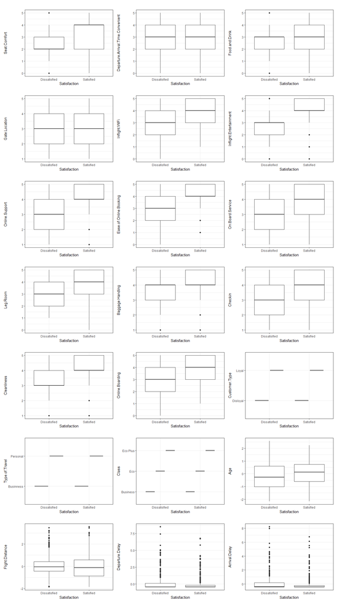

```r
pairs <- lapply(all_vars, function(v) {
  c("Satisfaction", v)
})

plots <- lapply(pairs, function(p) {
  cat_var <- p[1]
  num_var <- p[2]

  ggplot(table_full_std, aes(x = .data[[cat_var]], y = .data[[num_var]])) +
  geom_boxplot() +
  labs(
    x = cat_var,
    y = num_var,
    title =""
  ) +
  theme_bw()
})

wrap_plots(plots, ncol = 3)
```

### Barplots

Just to show the number of observations of each value of the categorical variables

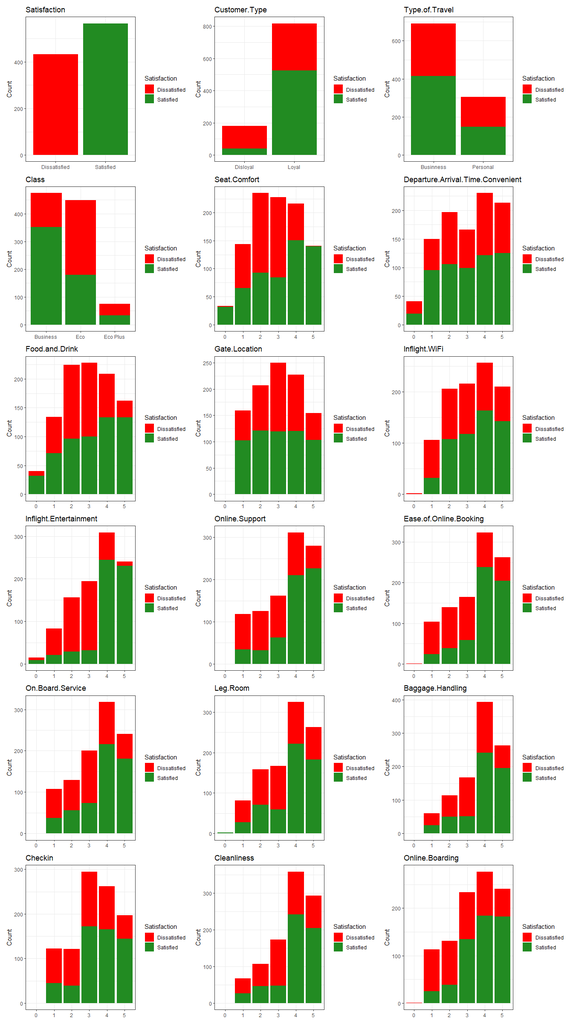

```r
plot_bar <- function(vars, scale = NULL) {
  x_scale <- if (!is.null(scale)) {
    scale_x_discrete(limits = scale)
  } else {
    NULL
  }

  plots <- lapply(vars, function(v) {
    ggplot(table, aes(
      x = factor(.data[[v]]),
      fill = factor(Satisfaction)
    )) +

    geom_bar() +

    x_scale +
    scale_fill_manual(
      values = c(
        "Dissatisfied" = "red",
        "Satisfied" = "forestgreen"
      )
    ) +

    labs(
      title = v,
      x = NULL,
      y = "Count",
      fill = "Satisfaction"
    ) +
    theme_bw()
  })
}


plots <- plot_bar(c(target_var, cat_vars))
plots <- c(plots, plot_bar(score_vars, c("0", "1", "2", "3", "4", "5")))

wrap_plots(plots, ncol = 3)
```

### Barplots Percentages

Here we show the percentages of satisfied/dissatisfied customers for each value of each categorical variable. This is somewhat more informative than the normal barplots, tho the trends can be approximated visually in the graphs above.

The only two exceptions that still have a significant number of observations are `Food.and.Drink` and `Seat.Comfort`: those might be outliers, `score = 0` yet satisfied.

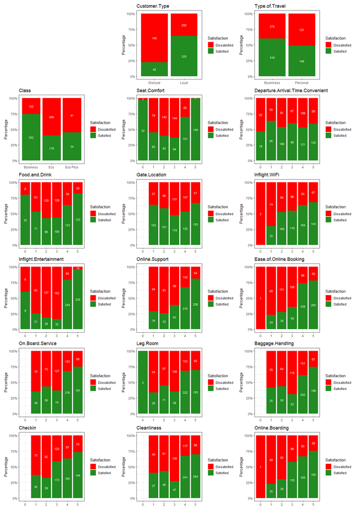

```r
plot_bar_perc <- function(vars, scale = NULL) {
  x_scale <- if (!is.null(scale)) {
    scale_x_discrete(limits = scale)
  } else {
    NULL
  }

  plots <- lapply(vars, function(v) {

    ggplot(table, aes(
      x = factor(.data[[v]]),
      fill = Satisfaction
    )) +
    geom_bar(position = "fill") +

    geom_text(
      stat = "count",
      aes(label = after_stat(count)),
      position = position_fill(vjust = 0.5),
      color = "white",
      size = 3
    ) +

    scale_y_continuous(labels = scales::percent) +
    x_scale +
    scale_fill_manual(
      values = c(
        "Dissatisfied" = "red",
        "Satisfied" = "forestgreen"
      )
    ) +

    labs(
      title = v,
      x = NULL,
      y = "Percentage",
      fill = "Satisfaction"
    ) +
    theme_bw()
  })
}


plots <- c(plot_spacer(), plot_bar_perc(cat_vars))
plots <- c(plots, plot_bar_perc(score_vars, c("0", "1", "2", "3", "4", "5")))

wrap_plots(plots, ncol = 3)
```

### Pairplots

Using only the numerical variables, since the scores are just a whole lot of overlapping points.

Those are not very informative imo.

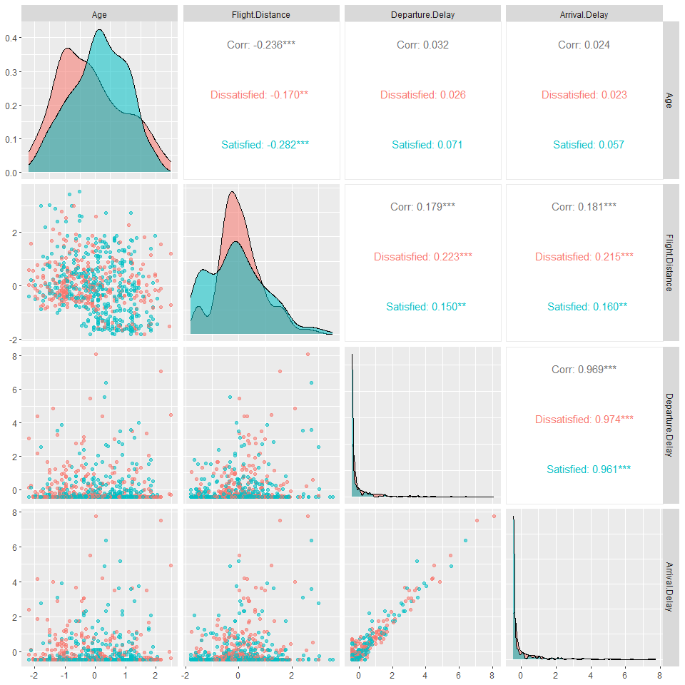

```r
ggpairs(
  table_std,
  columns = num_vars,
  aes(color = Satisfaction, alpha = 0.5)
)
```

## Correlation

From the correlation matrix we see that most predictors are uncorrelated, with a few exceptions, such as

- between the “Online” sth sth variables, which kinda makes sense, a good online service is good across all aspects.
- between the flight enjoyment variables (Seat.Comfort, Food.and.Drink, Inflight.Entertainment)
- `Departure.Delay` and `Arrival.Delay`: if you depart late, you will arrive late, thus almost full correlation.

and more with similar interpretations.

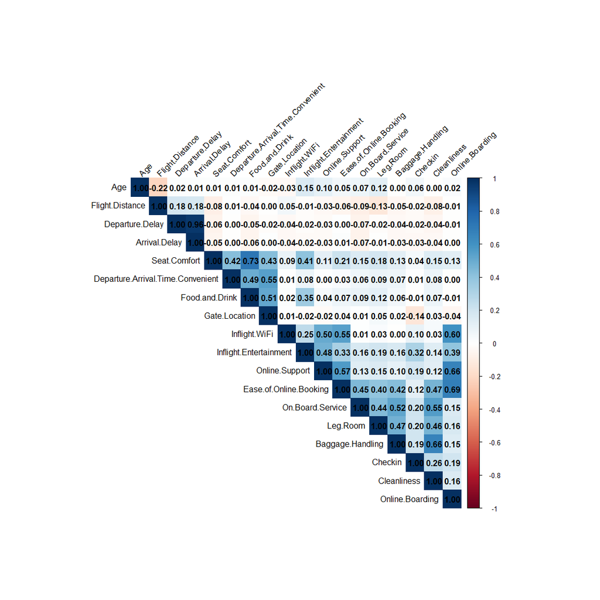

```r
corr_matrix <- cor(table_full_std[, c(num_vars, score_vars)], use = "complete.obs")

corrplot(corr_matrix,
         method = "color",
         type = "upper",
         addCoef.col = "black",
         tl.col = "black",
         tl.srt = 45)
```

# Initial Regression Model

Start by fitting a regression model using only the predictors

$$\texttt{Age},\ \texttt{SeatComfort},\
\texttt{FlightDistance},\ \texttt{Class},\ \texttt{DepartureDelay},\
\texttt{ArrivalDelay}$$

First of all, BAS is using BMA (Bayesian Model Averaging), so we train many models and give them a weight.

To interpret the summary:

- `P(B != 0 | Y)`: aka Posterior Inclusion Probability (PIP), how likely the variable belongs to the true model
- The 1/0 under the models for the first rows (those corresponding to the predictors): boolean flag, whether that predictor is included in the model
- `BF`: Bayes Factor, idk what it is but it’s a metric that compares each model with the best one, the higher the better, the best model has `BF = 1` by construction.
- `PostProb`: probability that that model is the true one, given the data
- `logmar`: the higher the better

In the summary of coefficients reports the average over the evaluated models weighted by their posterior probability, where

- `post mean`: average effect of a variable across all models, but models where the variable is absent count as 0 effect, so this is a shrunken, uncertainty-aware estimate.
- `post SD`: uncertainty on the effect, including the model uncertainty

In the graph of the residuals the x is the prediction in the log-odds scale (I assume / ChatGPT says). I have to admit that i really can’t understand that residual plot tho: when our model predicts log-odds = 0 (thus p(satisfied) = 0.5), we observe some residuals that are 0, which is impossible, any observations would either have satisfied = 0 or = 1, in both cases our prediction had a residual of 0.5. The same goes for residuals greater than 1. So maybe even the y is in the log-odds scale? but this still doesn’t make sense, consider the right side, i guess (ChatGPT says) that the two lines correspond to the two values satisfaction can assume, then when we predict 2 (p = 0.88), we have a residual of -2 for one class and -1 for the other, this means that we should have predicted 4 or 3 (to be exact for one class) (or equivalently predict 0 and 1) , but this means making a prediction where we are more strongly convinced that satisfaction = 1 (or = 0 equivalently) for both classes => contradiction… i just don’t know how to read it and ChatGPT isn’t helping.

Note: all the values are generated with some randomness, so they can change slightly, but the interpretation should remain the same

```r
fit <- bas.glm(
  Satisfaction ~ Age + Seat.Comfort + Flight.Distance + Class + Departure.Delay + Arrival.Delay,
  data = table_enc, family = binomial()
)

summary(fit)
```

```
                P(B != 0 | Y)   model 1      model 2      model 3     model 4      model 5
Intercept           1.0000000    1.0000    1.0000000    1.0000000    1.000000    1.0000000
Age                 0.4836585    0.0000    1.0000000    0.0000000    1.000000    0.0000000
Seat.Comfort        0.9998780    1.0000    1.0000000    1.0000000    1.000000    1.0000000
Flight.Distance     0.7391463    1.0000    1.0000000    1.0000000    1.000000    1.0000000
ClassEco            0.9989024    1.0000    1.0000000    1.0000000    1.000000    1.0000000
ClassEco Plus       0.9959756    1.0000    1.0000000    1.0000000    1.000000    1.0000000
Departure.Delay     0.5304878    1.0000    1.0000000    0.0000000    0.000000    0.0000000
Arrival.Delay       0.4469512    0.0000    0.0000000    1.0000000    1.000000    0.0000000
BF                         NA    1.0000    0.2559409    0.8220823    0.202804    0.8563443
PostProbs                  NA    0.1564    0.1340000    0.1233000    0.095000    0.0910000
R2                         NA    0.1611    0.1636000    0.1607000    0.163100    0.1552000
dim                        NA    6.0000    7.0000000    6.0000000    7.000000    5.0000000
logmarg                    NA -416.5355 -417.8983267 -416.7314327 -418.131033 -416.6906008
```

```r
coef(fit)
```

```
 Marginal Posterior Summaries of Coefficients:

 Using  BMA

 Based on the top  24 models
                 post mean  post SD   post p(B != 0)
Intercept        -0.10164    0.22017   1.00000
Age               0.07355    0.09930   0.48366
Seat.Comfort      0.44848    0.06637   0.99988
Flight.Distance  -0.16367    0.12776   0.73915
ClassEco         -1.66421    0.20779   0.99890
ClassEco Plus    -1.61675    0.34040   0.99598
Departure.Delay  -0.11812    0.17479   0.53049
Arrival.Delay    -0.06738    0.16536   0.44695
```

```r
print("--------------------------------------------", quote = FALSE)
```

```
[1] --------------------------------------------
```

```r
confint(coef(fit))
```

```
                        2.5%       97.5%        beta
Intercept       -0.519257714  0.34482323 -0.10163697
Age             -0.000277507  0.29734428  0.07354790
Seat.Comfort     0.315502925  0.57536357  0.44847887
Flight.Distance -0.370988617  0.00000000 -0.16367400
ClassEco        -2.060077948 -1.27404695 -1.66420567
ClassEco Plus   -2.265149985 -0.96550640 -1.61675408
Departure.Delay -0.513103852  0.08909683 -0.11811754
Arrival.Delay   -0.407512881  0.24572457 -0.06738272
attr(,"Probability")
[1] 0.95
attr(,"class")
[1] "confint.bas"
```

```r
par(mfrow = c(2, 2))

plot(fit, which = 1)
plot(fit, which = 2)
```

```r
plot(fit, which = 3)
plot(fit, which = 4)
```

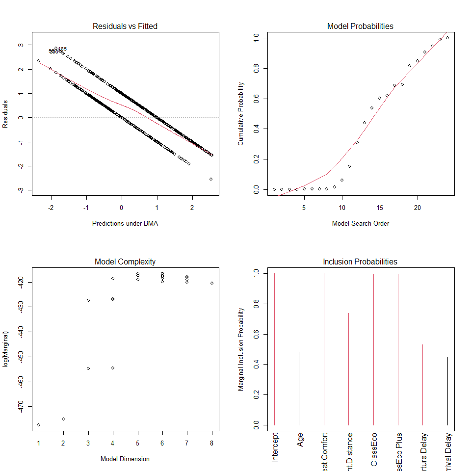

```r
par(mfrow = c(1, 1))
```

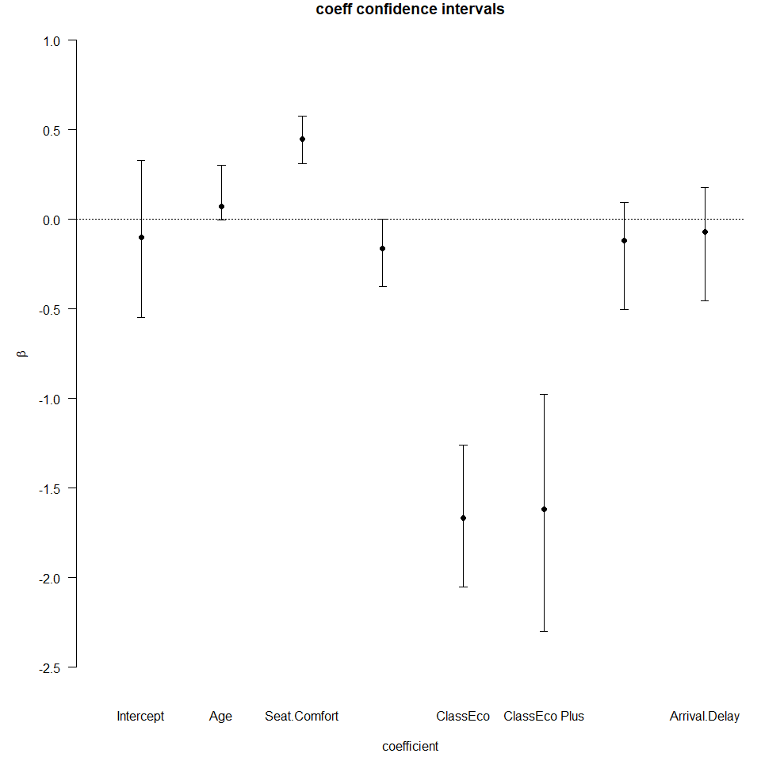

```r
plot(confint(coef(fit)), main="coeff confidence intervals")
```

## Seat.Comfort as Categorical

Much slower but gives a better R2, however there are some weird things. We can expect a model deciding to exclude Seat.Comfort as a whole to make predictions, however here (since it’s treated as 5 distinct variables) it can happen (as in model 1) that only a subset of the levels is selected, and others are ignored. Now, if the selected ones where all the k highest levels it would be fine (it means “if the score is above below a certain value, it might as well be treated as a 0 (which is the baseline level)”), however we see that level 5 is ignored, which means “if the observation has score = 5, it is equivalent to score = 0” which is clearly wrong. The solutions to this are three: group priors (idk what they are), hierarchical structure (idk what it is) or treating the factors as numeric, as done above.

This still has a better R2 (not that it was hard to be better than the previous model), but i still struggle to understand the residual plot.

```r
table_cat <- table_enc %>%
  mutate(across(c(Seat.Comfort), as.factor))

fit_cat <- bas.glm(
  Satisfaction ~ Age + Seat.Comfort + Flight.Distance + Class + Departure.Delay + Arrival.Delay,
  data = table_cat, family = binomial()
)

summary(fit_cat)
```

```
                P(B != 0 | Y)   model 1     model 2     model 3      model 4      model 5
Intercept           1.0000000    1.0000    1.000000    1.000000    1.0000000    1.0000000
Age                 0.4142276    0.0000    0.000000    0.000000    1.0000000    1.0000000
Seat.Comfort1       0.9983740    1.0000    1.000000    1.000000    1.0000000    1.0000000
Seat.Comfort2       0.9992683    1.0000    1.000000    1.000000    1.0000000    1.0000000
Seat.Comfort3       0.9993496    1.0000    1.000000    1.000000    1.0000000    1.0000000
Seat.Comfort4       0.9983740    1.0000    1.000000    1.000000    1.0000000    1.0000000
Seat.Comfort5       0.2700813    0.0000    0.000000    0.000000    0.0000000    0.0000000
Flight.Distance     0.4653659    0.0000    0.000000    1.000000    0.0000000    0.0000000
ClassEco            1.0000000    1.0000    1.000000    1.000000    1.0000000    1.0000000
ClassEco Plus       0.9998374    1.0000    1.000000    1.000000    1.0000000    1.0000000
Departure.Delay     0.5322764    1.0000    0.000000    1.000000    1.0000000    0.0000000
Arrival.Delay       0.4586992    0.0000    1.000000    0.000000    0.0000000    1.0000000
BF                         NA    1.0000    0.774907    0.340285    0.3354135    0.2510751
PostProbs                  NA    0.0932    0.092600    0.068700    0.0676000    0.0515000
R2                         NA    0.3098    0.309300    0.312600    0.3125000    0.3119000
dim                        NA    8.0000    8.000000    9.000000    9.0000000    9.0000000
logmarg                    NA -350.7328 -350.987837 -351.810797 -351.8252163 -352.1148281
```

```r
coef(fit_cat)
```

```
 Marginal Posterior Summaries of Coefficients:

 Using  BMA

 Based on the top  47 models
                 post mean  post SD    post p(B != 0)
Intercept          9.05258  236.72280    1.00000
Age                0.05487    0.09155    0.41423
Seat.Comfort1     -8.13873  235.34100    0.99837
Seat.Comfort2     -8.50738  235.34097    0.99927
Seat.Comfort3     -8.71656  235.34095    0.99935
Seat.Comfort4     -6.88927  235.34098    0.99837
Seat.Comfort5     -3.10234  235.34180    0.27008
Flight.Distance   -0.07126    0.10506    0.46537
ClassEco          -1.83609    0.21810    1.00000
ClassEco Plus     -2.09641    0.39170    0.99984
Departure.Delay   -0.12569    0.20436    0.53228
Arrival.Delay     -0.04752    0.19374    0.45870
```

```r
print("--------------------------------------------", quote = FALSE)
```

```
[1] --------------------------------------------
```

```r
confint(coef(fit_cat))
```

```
                         2.5%        97.5%        beta
Intercept       -614.52727364 611.21652615  9.05257729
Age               -0.02564699   0.28944962  0.05487012
Seat.Comfort1   -644.46769715 573.79463570 -8.13872676
Seat.Comfort2   -644.84213203 573.42344395 -8.50738407
Seat.Comfort3   -645.04380480 573.23334602 -8.71656115
Seat.Comfort4   -643.23767994 575.02898164 -6.88926825
Seat.Comfort5   -639.60781770 578.69730266 -3.10233771
Flight.Distance   -0.32080695   0.01993584 -0.07125598
ClassEco          -2.26903045  -1.41582340 -1.83608815
ClassEco Plus     -2.86459315  -1.33040634 -2.09641425
Departure.Delay   -0.66015984   0.09357794 -0.12569289
Arrival.Delay     -0.45234753   0.35340706 -0.04752011
attr(,"Probability")
[1] 0.95
attr(,"class")
[1] "confint.bas"
```

```r
par(mfrow = c(2, 2))

plot(fit_cat, which = 1)
plot(fit_cat, which = 2)
```

```r
plot(fit_cat, which = 3)
plot(fit_cat, which = 4)
```

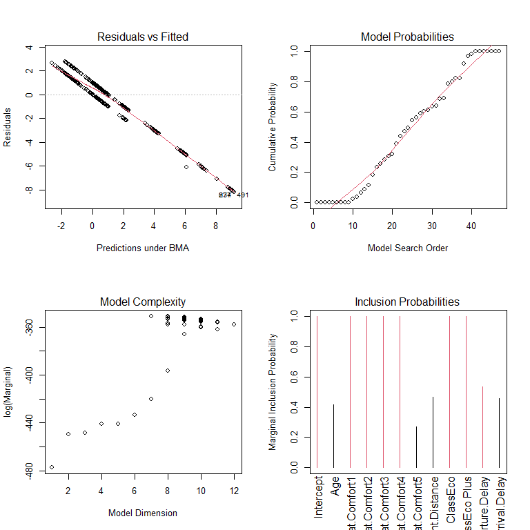

```r
par(mfrow = c(1, 1))
```

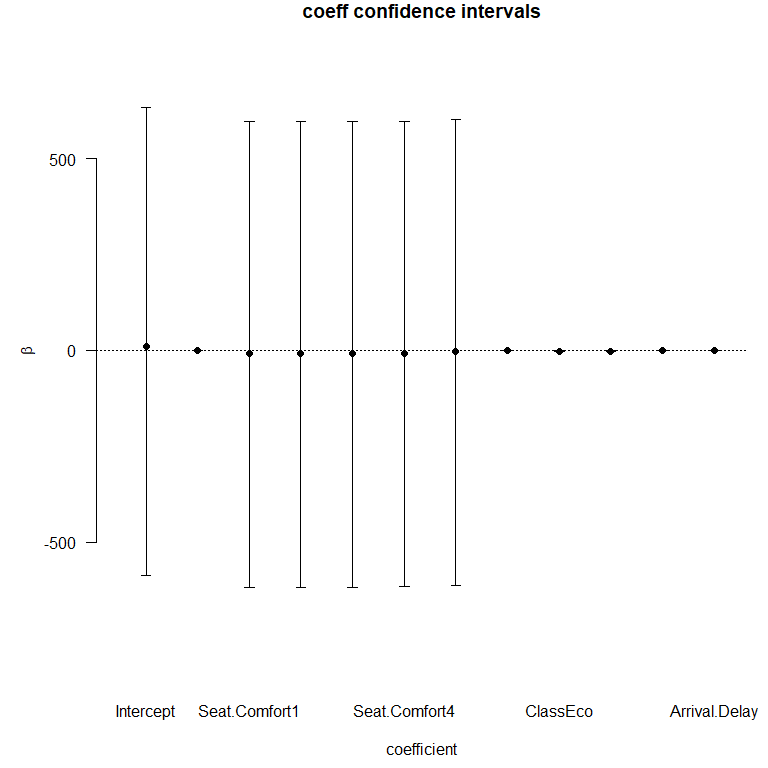

```r
plot(confint(coef(fit_cat)),main="coeff confidence intervals")
```

# Full Model

The initial model used only 6 predictors. We now extend the analysis to all available covariates to identify which variables are most strongly associated with customer satisfaction.

With 21 predictors the full model space ($2^{21}$) is too large to enumerate exactly. `bas.glm` uses MCMC sampling over the model space, visiting models proportionally to their posterior probability.

```r
fit_full <- bas.glm(
  Satisfaction ~ . - Satisfaction - X,
  data            = table_enc,
  family          = binomial(),
  method          = "MCMC",
  MCMC.iterations = 10000
)

# ?? i don't know if we need to add:  prior = "BIC"

round(summary(fit_full), 3)
```

```
                                  P(B != 0 | Y)  model 1  model 2  model 3  model 4  model 5
Intercept                                 1.000    1.000    1.000    1.000    1.000    1.000
Customer.TypeLoyal                        0.998    1.000    1.000    1.000    1.000    1.000
Age                                       0.196    0.000    0.000    0.000    0.000    0.000
Type.of.TravelPersonal                    0.578    0.000    1.000    0.000    1.000    1.000
ClassEco                                  0.967    1.000    1.000    1.000    1.000    1.000
ClassEco Plus                             0.761    1.000    1.000    1.000    0.000    0.000
Flight.Distance                           0.422    0.000    0.000    0.000    0.000    0.000
Seat.Comfort                              0.958    1.000    1.000    1.000    1.000    1.000
Departure.Arrival.Time.Convenient         0.394    0.000    0.000    0.000    0.000    0.000
Food.and.Drink                            0.957    1.000    1.000    1.000    1.000    1.000
Gate.Location                             0.313    0.000    0.000    0.000    0.000    0.000
Inflight.WiFi                             0.190    0.000    0.000    0.000    0.000    0.000
Inflight.Entertainment                    0.998    1.000    1.000    1.000    1.000    1.000
Online.Support                            0.260    0.000    0.000    0.000    0.000    0.000
Ease.of.Online.Booking                    0.993    1.000    1.000    1.000    1.000    1.000
On.Board.Service                          0.796    0.000    1.000    1.000    1.000    1.000
Leg.Room                                  0.208    0.000    0.000    0.000    0.000    0.000
Baggage.Handling                          0.311    0.000    0.000    0.000    0.000    0.000
Checkin                                   0.391    0.000    0.000    0.000    1.000    1.000
Cleanliness                               0.326    1.000    0.000    0.000    0.000    0.000
Online.Boarding                           0.168    0.000    0.000    0.000    0.000    0.000
Departure.Delay                           0.358    0.000    0.000    0.000    1.000    0.000
Arrival.Delay                             0.739    1.000    1.000    1.000    0.000    1.000
BF                                           NA    0.275    0.646    1.000    0.272    0.417
PostProbs                                    NA    0.013    0.010    0.008    0.007    0.007
R2                                           NA    0.449    0.456    0.452    0.454    0.455
dim                                          NA   10.000   11.000   10.000   11.000   11.000
logmarg                                      NA -289.361 -288.506 -288.070 -289.371 -288.943
```

**Image plot** : each column is one of the top-visited models (ranked by posterior probability); each row is a predictor. A coloured cell means the predictor is included in that model. Variables that appear coloured across almost all columns have high posterior inclusion probability and are consistently selected.

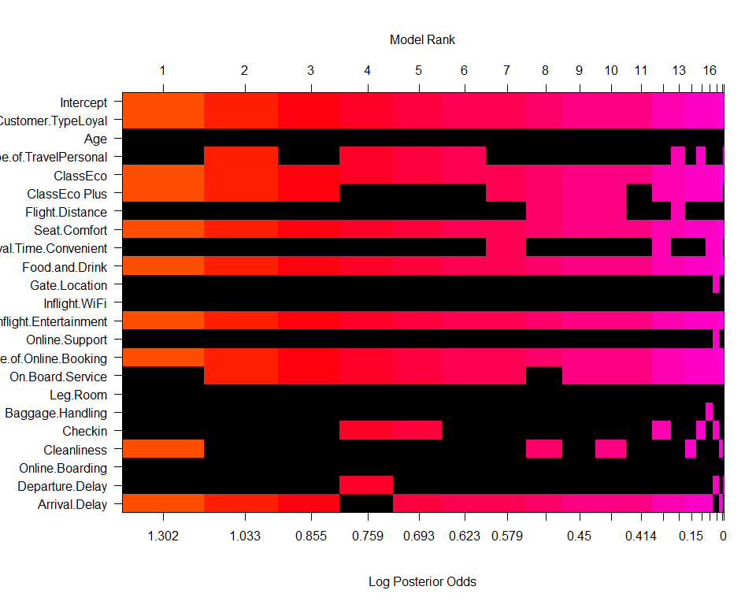

```r
image(fit_full, rotate = FALSE)
```

**Posterior Inclusion Probabilities (PIPs)**: we extract and rank the PIPs to identify the most important predictors:

```r
pip_full <- data.frame(
  variable = fit_full$namesx,
  PIP      = fit_full$probne0,
  coeff    = coef(fit_full)$postmean
)
pip_full <- pip_full[order(pip_full$PIP, decreasing = TRUE), ]
pip_full
```

|  | variable | PIP | coeff |
| --- | --- | --- | --- |
| 1 | Intercept | 1.0000000 | -7.203006198 |
| 13 | Inflight.Entertainment | 0.9982033 | 1.007127990 |
| 2 | Customer.TypeLoyal | 0.9977305 | 1.806495690 |
| 15 | Ease.of.Online.Booking | 0.9930024 | 0.497670241 |
| 5 | ClassEco | 0.9666194 | -1.118822965 |
| 8 | Seat.Comfort | 0.9582033 | 0.437534912 |
| 10 | Food.and.Drink | 0.9568794 | -0.424926717 |
| 16 | On.Board.Service | 0.7956501 | 0.236380955 |
| 6 | ClassEco Plus | 0.7609456 | -0.933122527 |
| 23 | Arrival.Delay | 0.7389125 | -0.315176620 |

[output cut: 13 more lines]

Variables with PIP close to 1 are consistently selected across nearly all visited models and should be considered the key drivers of satisfaction.

**Highest Posterior Model (HPM)**

```r
# Index of the model with larger log-likehood
best_idx <- which.max(fit_full$logmarg)

# Considered variable
hpm_vars <- fit_full$which[[best_idx]]
cat("Variables in the model HPM (indexes):", hpm_vars, "\n")
```

```
Variables in the model HPM (indexes): 0 1 4 5 7 9 12 14 15 22
```

```r
cat("Name:", fit_full$namesx[hpm_vars + 1], "\n")
```

```
Name: Intercept Customer.TypeLoyal ClassEco ClassEco Plus Seat.Comfort Food.and.Drink Inflight.Entertainment Ease.of.Online.Booking On.Board.Service Arrival.Delay
```

```r
# Posterior probability of the model HPM vs runner-up
pp_sorted <- sort(fit_full$postprobs, decreasing = TRUE)
cat("\nPosterior probability HPM:      ", round(pp_sorted[1], 4), "\n")
```

```
Posterior probability HPM:       0.0129
```

```r
cat("Posterior probability runner-up:", round(pp_sorted[2], 4), "\n")
```

```
Posterior probability runner-up: 0.0098
```

```r
coef_full <- coef(fit_full, estimator = "BMA")
coef_full
```

```
 Marginal Posterior Summaries of Coefficients:

 Using  BMA

 Based on the top  2185 models
                                   post mean  post SD    post p(B != 0)
Intercept                          -7.203006   0.914190   1.000000
Customer.TypeLoyal                  1.806496   0.398773   0.997730
Age                                -0.021171   0.068455   0.196028
Type.of.TravelPersonal             -0.451177   0.489822   0.577589
ClassEco                           -1.118823   0.440230   0.966619
ClassEco Plus                      -0.933123   0.671765   0.760946
Flight.Distance                    -0.090484   0.132350   0.422128
Seat.Comfort                        0.437535   0.158147   0.958203
Departure.Arrival.Time.Convenient  -0.064229   0.098859   0.394137
Food.and.Drink                     -0.424927   0.160344   0.956879
Gate.Location                       0.047035   0.093970   0.313002
Inflight.WiFi                      -0.010756   0.056774   0.190355
Inflight.Entertainment              1.007128   0.129462   0.998203
Online.Support                      0.035396   0.085185   0.259574
Ease.of.Online.Booking              0.497670   0.140689   0.993002
On.Board.Service                    0.236381   0.158821   0.795650
Leg.Room                            0.020611   0.060381   0.208132
Baggage.Handling                    0.049217   0.102853   0.310922
Checkin                             0.064588   0.100927   0.391300
Cleanliness                         0.058534   0.114979   0.326430
Online.Boarding                    -0.008266   0.059829   0.168322
Departure.Delay                    -0.108329   0.230893   0.357541
Arrival.Delay                      -0.315177   0.249838   0.738913
```

```r
print("--------------------------------------------", quote = FALSE)
```

```
[1] --------------------------------------------
```

```r
confint(coef_full)
```

```
                                           2.5%         97.5%         beta
Intercept                         -9.0101394157 -5.458001e+00 -7.203006198
Customer.TypeLoyal                 1.0756609445  2.590219e+00  1.806495690
Age                               -0.2560301830  2.244975e-02 -0.021170726
Type.of.TravelPersonal            -1.4235797768  0.000000e+00 -0.451176504
ClassEco                          -1.7470349958  1.437996e-05 -1.118822965
ClassEco Plus                     -1.9528426923  0.000000e+00 -0.933122527
Flight.Distance                   -0.3838274337  0.000000e+00 -0.090484182
Seat.Comfort                       0.0000000000  6.702554e-01  0.437534912
Departure.Arrival.Time.Convenient -0.2886308678  0.000000e+00 -0.064229044
Food.and.Drink                    -0.6597818245  0.000000e+00 -0.424926717
Gate.Location                     -0.0018598970  3.064273e-01  0.047035116
Inflight.WiFi                     -0.1828713341  9.281190e-02 -0.010756213
Inflight.Entertainment             0.7551538106  1.242275e+00  1.007127990
Online.Support                    -0.0122255865  2.764230e-01  0.035395539
Ease.of.Online.Booking             0.2184299675  7.753808e-01  0.497670241
On.Board.Service                   0.0000000000  4.816125e-01  0.236380955
Leg.Room                          -0.0132449211  2.171797e-01  0.020610762
Baggage.Handling                  -0.0271388341  3.281020e-01  0.049216825
Checkin                           -0.0001687681  2.973649e-01  0.064588454
Cleanliness                       -0.0047609791  3.778356e-01  0.058533884
Online.Boarding                   -0.1890417738  1.042840e-01 -0.008265976
Departure.Delay                   -0.7035007930  6.232710e-02 -0.108329437
Arrival.Delay                     -0.6997755665  0.000000e+00 -0.315176620
attr(,"Probability")
[1] 0.95
attr(,"class")
[1] "confint.bas"
```

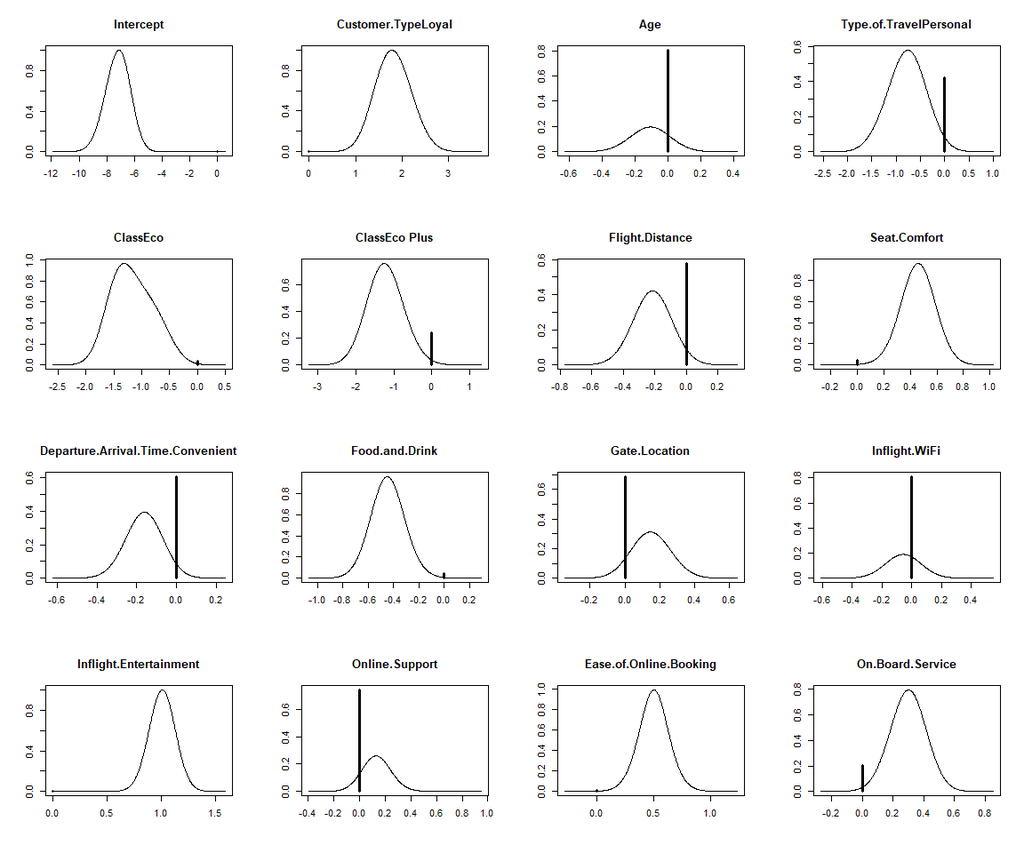

```r
par(mfrow = c(4, 4))
plot(coef_full, ask = FALSE)
```

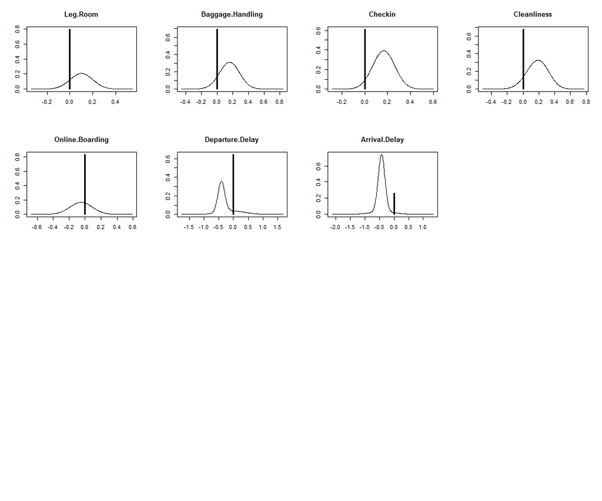

```r
par(mfrow = c(1, 1))
```

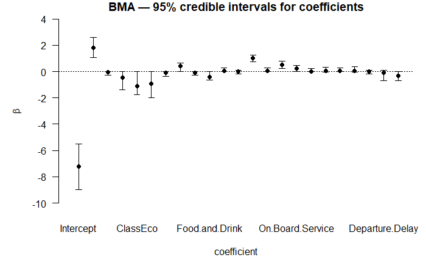

```r
plot(confint(coef_full), main = "BMA — 95% credible intervals for coefficients")
```

```r
par(mfrow = c(2, 2))

plot(fit_full, which = 1)
plot(fit_full, which = 2)
```

```r
plot(fit_full, which = 3)
plot(fit_full, which = 4)
```

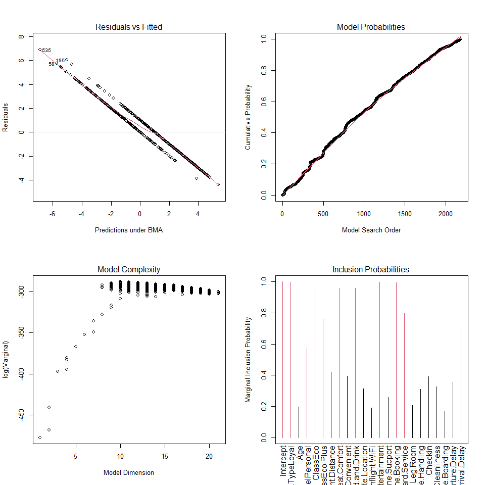

```r
par(mfrow = c(1, 1))
```

**Interpretation of PIP and coefficients:**

NOTE: the following depend heavily on the train-test split (in fact they are not up to date, just refer to the PIP table above), can we TODO sth about this variability? like stratification

# Variable Selection

In principle we could use the HPM as a form of variable selection, however it can be very unstable (as always due to the presence of correlated predictors), since it does not account for the model uncertainty, unless `PostProb` is concentrated in one model.

## PIP Threshold

Starting from the full model we see that many variables have low PIP, this confirms our belief that many predictors captured redundant information (e.g. `Arrival.Delay` is a consequence of `Departure.Delay`).

We can start by fitting a simpler model where we consider only the variables with PIP above a certain threshold.

Notice that

- the PIP threshold might separate the dummy variables for categorical predictors => in the model I must use the original variable
- now all predictors have high PIP, even those that had PIP slightly above the threshold in the full model, this is due to the removal of the correlated predictors that shared part of the PIP.
- the model is now small enough to train it without MCMC
- only one model (the one with all predictors) has a high `PostProb`, meaning that the predictions will be heavily influenced by that single model, but it’s not that strong to state that there is no model uncertainty

```r
# TODO: try other thresholds?
#       maybe by looking at the sorted list of pip seeing if we missed sth important (that's not correlated to what we have selected)
#       or included sth useless

vars_th <- pip_full$variable[pip_full$PIP > 0.5]
vars_th <- setdiff(vars_th, "Intercept")
cat("Selected using PIP threshold: ", vars_th, "\n")
```

```
Selected using PIP threshold:  Inflight.Entertainment Customer.TypeLoyal Ease.of.Online.Booking ClassEco Seat.Comfort Food.and.Drink On.Board.Service ClassEco Plus Arrival.Delay Type.of.TravelPersonal
```

```r
# TODO: automate the model construction, for the cat variables we should do sth like if (vars_th[i].starts_with(cat_vars[j for some j])) then use cat_vars[j]

fit_th <- bas.glm(
  Satisfaction ~
    Customer.Type + Inflight.Entertainment + Ease.of.Online.Booking + Class +
    Seat.Comfort + On.Board.Service + Type.of.Travel + Arrival.Delay + Food.and.Drink,
  data = table_enc, family = binomial()
)

summary(fit_th)
```

```
                       P(B != 0 | Y)      model 1   model 2     model 3      model 4      model 5
Intercept                  1.0000000    1.0000000    1.0000    1.000000    1.0000000    1.0000000
Customer.TypeLoyal         0.9995565    1.0000000    1.0000    1.000000    1.0000000    1.0000000
Inflight.Entertainment     0.9990244    1.0000000    1.0000    1.000000    1.0000000    1.0000000
Ease.of.Online.Booking     0.9997339    1.0000000    1.0000    1.000000    1.0000000    1.0000000
ClassEco                   0.9886475    1.0000000    1.0000    1.000000    0.0000000    1.0000000
ClassEco Plus              0.9193792    1.0000000    1.0000    0.000000    0.0000000    1.0000000
Seat.Comfort               0.9958315    1.0000000    1.0000    1.000000    1.0000000    1.0000000
On.Board.Service           0.9898004    1.0000000    1.0000    1.000000    1.0000000    0.0000000
Type.of.TravelPersonal     0.8611086    1.0000000    0.0000    1.000000    1.0000000    0.0000000
Arrival.Delay              0.9968071    1.0000000    1.0000    1.000000    1.0000000    1.0000000
Food.and.Drink             0.9962749    1.0000000    1.0000    1.000000    1.0000000    1.0000000
BF                                NA    0.6462963    1.0000    0.525931    0.1544457    0.1008198
PostProbs                         NA    0.7778000    0.1258    0.067000    0.0070000    0.0053000
R2                                NA    0.4557000    0.4518    0.450500    0.4430000    0.4421000
dim                               NA   11.0000000   10.0000   10.000000    9.0000000    9.0000000
logmarg                           NA -288.5061461 -288.0696 -288.712234 -289.9375617 -290.3640691
```

```r
coef(fit_th)
```

```
 Marginal Posterior Summaries of Coefficients:

 Using  BMA

 Based on the top  31 models
                        post mean  post SD  post p(B != 0)
Intercept               -6.9710     0.7111   1.0000
Customer.TypeLoyal       1.8068     0.3581   0.9996
Inflight.Entertainment   1.0431     0.1159   0.9990
Ease.of.Online.Booking   0.5185     0.1025   0.9997
ClassEco                -1.0407     0.3512   0.9886
ClassEco Plus           -0.9491     0.5244   0.9194
Seat.Comfort             0.4626     0.1305   0.9958
On.Board.Service         0.3314     0.1074   0.9898
Type.of.TravelPersonal  -0.5603     0.3873   0.8611
Arrival.Delay           -0.4385     0.1126   0.9968
Food.and.Drink          -0.4651     0.1252   0.9963
```

```r
print("--------------------------------------------", quote = FALSE)
```

```
[1] --------------------------------------------
```

```r
confint(coef(fit_th))
```

```
                             2.5%         97.5%       beta
Intercept              -8.3479944 -5.5999476546 -6.9709521
Customer.TypeLoyal      1.1016219  2.5137339939  1.8067972
Inflight.Entertainment  0.8204921  1.2625284790  1.0431145
Ease.of.Online.Booking  0.3262185  0.7320154100  0.5184675
ClassEco               -1.7398656 -0.3749184619 -1.0407466
ClassEco Plus          -1.8419004  0.0001131357 -0.9491326
Seat.Comfort            0.2136213  0.7308010913  0.4626492
On.Board.Service        0.1226355  0.5450711991  0.3313853
Type.of.TravelPersonal -1.3031990  0.0079347321 -0.5603337
Arrival.Delay          -0.6590523 -0.2165870055 -0.4384980
Food.and.Drink         -0.7134874 -0.2183961779 -0.4650560
attr(,"Probability")
[1] 0.95
attr(,"class")
[1] "confint.bas"
```

```r
par(mfrow = c(2, 2))

plot(fit_th, which = 1)
plot(fit_th, which = 2)
```

```r
plot(fit_th, which = 3)
plot(fit_th, which = 4)
```

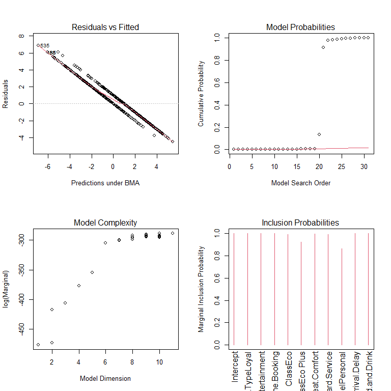

```r
par(mfrow = c(1, 1))
```

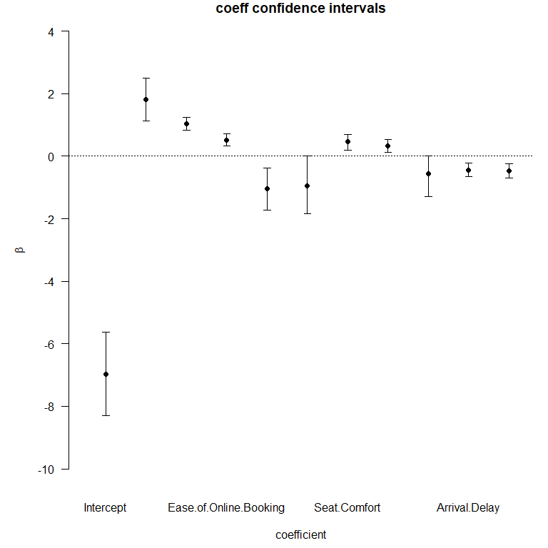

```r
plot(confint(coef(fit_th)), main="coeff confidence intervals")
```

This approach is simple, however we should compare carefully it’s performance compared to the full model, because we have many strongly correlated predictors, so PIP might be split among them (e.g. one predictor could have PIP = 0.9, but the presence of a second predictor that captures the same information yields both PIP = 0.45). This means that we might have removed the predictors that captured that information, losing it.

For this reason we might want to manually choose a subset of the predictors excluding those that are strongly correlated to the selected ones and fit such a model.

## Manual Selection

The following variables have been chosen based on

- the box-plots, picking the variables that show the most clear division between satisfied and dissatisfied customers,
- the correlation matrix, trying not to pick two strongly correlated variables.
- the knowledge of the problem: a loyal customer is more likely to be satisfied otherwise he wouldn’t be loyal in the first place, delays sure lower the satisfaction and so on…

Now, this model isn’t much simpler than the threshold one (just 1 less variable) (and not very different either) so we might leave this just as “sth we tested” or make it even simpler and see how it goes (but i wouldn’t know what to remove, it already seems the bare minimum to make a decision about satisfaction).

```r
fit_man <- bas.glm(
  Satisfaction ~
    Customer.Type + Arrival.Delay + Inflight.Entertainment + Online.Boarding +
    Cleanliness + Class + Type.of.Travel + Seat.Comfort,
  data = table_enc, family = binomial()
)

summary(fit_man)
```

```
                       P(B != 0 | Y)      model 1   model 2     model 3      model 4      model 5
Intercept                  1.0000000    1.0000000    1.0000    1.000000    1.0000000    1.0000000
Customer.TypeLoyal         0.9976585    1.0000000    1.0000    1.000000    1.0000000    1.0000000
Arrival.Delay              0.9923902    1.0000000    1.0000    1.000000    1.0000000    1.0000000
Inflight.Entertainment     0.9991220    1.0000000    1.0000    1.000000    1.0000000    1.0000000
Online.Boarding            0.9961951    1.0000000    1.0000    1.000000    1.0000000    1.0000000
Cleanliness                0.9993171    1.0000000    1.0000    1.000000    1.0000000    1.0000000
ClassEco                   0.9840976    1.0000000    1.0000    1.000000    1.0000000    1.0000000
ClassEco Plus              0.9705366    1.0000000    1.0000    1.000000    1.0000000    0.0000000
Type.of.TravelPersonal     0.8683902    1.0000000    0.0000    1.000000    0.0000000    1.0000000
Seat.Comfort               0.9021463    1.0000000    1.0000    0.000000    0.0000000    1.0000000
BF                                NA    0.6598737    1.0000    0.517782    0.7335963    0.1287432
PostProbs                         NA    0.7713000    0.1042    0.063100    0.0224000    0.0143000
R2                                NA    0.4178000    0.4138    0.412400    0.4081000    0.4095000
dim                               NA   10.0000000    9.0000    9.000000    8.0000000    9.0000000
logmarg                           NA -304.2753540 -303.8596 -304.517848 -304.1694435 -305.9095829
```

```r
coef(fit_man)
```

```
 Marginal Posterior Summaries of Coefficients:

 Using  BMA

 Based on the top  30 models
                        post mean  post SD   post p(B != 0)
Intercept               -7.44449    0.73077   1.00000
Customer.TypeLoyal       1.94503    0.35344   0.99766
Arrival.Delay           -0.44482    0.12423   0.99239
Inflight.Entertainment   0.88872    0.11128   0.99912
Online.Boarding          0.36454    0.09217   0.99620
Cleanliness              0.52323    0.09451   0.99932
ClassEco                -0.96572    0.33170   0.98410
ClassEco Plus           -1.14916    0.46498   0.97054
Type.of.TravelPersonal  -0.53265    0.36004   0.86839
Seat.Comfort             0.17833    0.10147   0.90215
```

```r
print("--------------------------------------------", quote = FALSE)
```

```
[1] --------------------------------------------
```

```r
confint(coef(fit_man))
```

```
                                2.5%       97.5%       beta
Intercept              -8.8544363824 -6.02609694 -7.4444871
Customer.TypeLoyal      1.2951737775  2.64875243  1.9450314
Arrival.Delay          -0.6928074619 -0.21354443 -0.4448248
Inflight.Entertainment  0.6798638204  1.10632186  0.8887201
Online.Boarding         0.1917604706  0.54627086  0.3645447
Cleanliness             0.3417287910  0.70976058  0.5232288
ClassEco               -1.6264976606 -0.32543932 -0.9657225
ClassEco Plus          -1.8887603457  0.00000000 -1.1491565
Type.of.TravelPersonal -1.1901755548  0.01514488 -0.5326508
Seat.Comfort           -0.0002924535  0.34885786  0.1783315
attr(,"Probability")
[1] 0.95
attr(,"class")
[1] "confint.bas"
```

```r
par(mfrow = c(2, 2))

plot(fit_man, which = 1)
plot(fit_man, which = 2)
```

```r
plot(fit_man, which = 3)
plot(fit_man, which = 4)
```

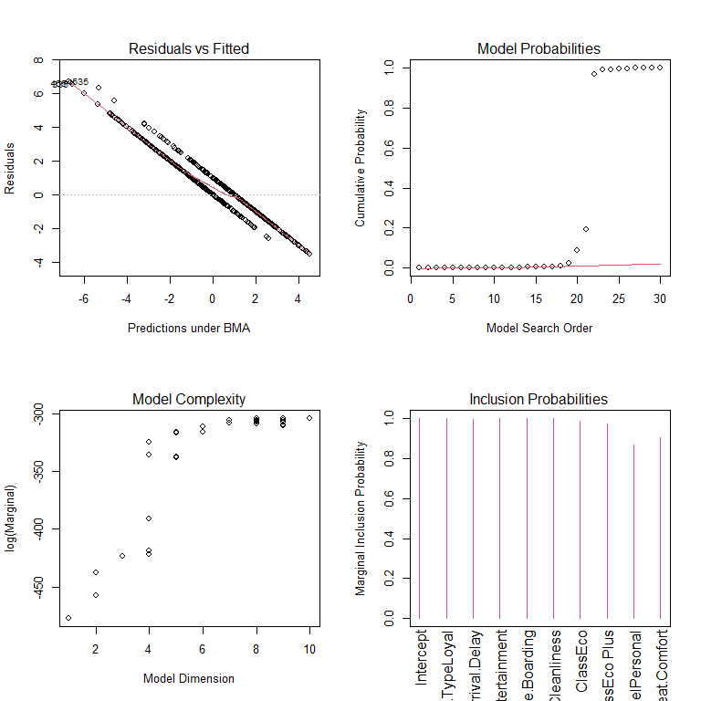

```r
par(mfrow = c(1, 1))
```

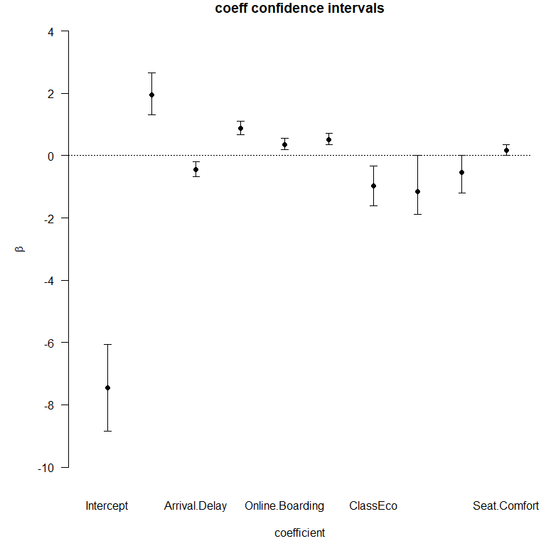

```r
plot(confint(coef(fit_man)), main="coeff confidence intervals")
```

# Transforming Predictors

## Clustering Correlated Predictors

From the knowledge of the problem domain, we can also identify some clusters of features:

- Digital experience cluster: `Inflight.WiFi`, `Inflight.Entertainment`, `Online.Support`, `Ease.of.Online.Booking`, `Online.Boarding`
- On-board service cluster: `On.Board.Service`, `Leg.Room`, `Cleanliness`, `Baggage.Handling`, `Checkin`

Given the correlation matrix we see that the members of the first cluster are also highly correlated (maybe excluding `Inflight.Entertainment`) so we can try to merge them in a single feature that summarizes the whole effect. We could for instance take the average score across the predictors in the cluster (or better do PCA, but i refuse to think about ASS more than the strict necessary however).

## Other Transformations

?? Do we want to try sth for this, maybe squaring the scores can give a much stronger effect on the 5/5 scores, but do we suspect a quadratic relationship with the target? also the numeric features don’t seem to have any particular pattern in the pairplots so i wouldn’t transform them.

## Interaction Features

?? Do we suspect interactions? like idk `Flight.Entertainment` is relevant only when in business class or the combo `Seat.Comfort` and `Leg.Room` is stronger than the two individual effects so we should multiply them or sth like that… I think we have a looot of pussybilities (cit) so we should focus on the phenomena that we suspect are happening given our knowledge of planes. I know a lot about them from the outside, but ive never taken one so lemme know.

Motivation: Business class passengers have different expectations than Economy passengers. The effect of in-flight services on satisfaction may therefore depend on the travel class. We test two interactions: Class:Inflight.Entertainment and Class:Seat.Comfort

```r
fit_int <- bas.glm(
  Satisfaction ~
    Customer.Type + Inflight.Entertainment + Ease.of.Online.Booking + Class +
    Seat.Comfort + On.Board.Service + Type.of.Travel + Arrival.Delay +
    Class:Inflight.Entertainment + Class:Seat.Comfort,
  data            = table_enc,
  family          = binomial(),
  method          = "MCMC",
  MCMC.iterations = 10000
)

summary(fit_int)
```

```
                                     P(B != 0 | Y)      model 1   model 2      model 3    model 4      model 5
Intercept                                1.0000000    1.0000000    1.0000    1.0000000    1.00000    1.0000000
Customer.TypeLoyal                       0.9998068    1.0000000    1.0000    1.0000000    1.00000    1.0000000
Inflight.Entertainment                   0.9988406    1.0000000    1.0000    1.0000000    1.00000    1.0000000
Ease.of.Online.Booking                   0.9987440    1.0000000    1.0000    1.0000000    1.00000    1.0000000
ClassEco                                 0.4213527    0.0000000    0.0000    1.0000000    0.00000    0.0000000
ClassEco Plus                            0.3584541    0.0000000    0.0000    0.0000000    1.00000    0.0000000
Seat.Comfort                             0.3104348    0.0000000    0.0000    0.0000000    0.00000    0.0000000
On.Board.Service                         0.9629952    1.0000000    1.0000    1.0000000    1.00000    1.0000000
Type.of.TravelPersonal                   0.5916908    1.0000000    0.0000    1.0000000    1.00000    1.0000000
Arrival.Delay                            0.9929469    1.0000000    1.0000    1.0000000    1.00000    1.0000000
Inflight.Entertainment:ClassEco          0.6482126    1.0000000    1.0000    0.0000000    1.00000    1.0000000
Inflight.Entertainment:ClassEco Plus     0.5235749    1.0000000    1.0000    1.0000000    0.00000    0.0000000
ClassEco:Seat.Comfort                    0.2307246    0.0000000    0.0000    0.0000000    0.00000    0.0000000
ClassEco Plus:Seat.Comfort               0.2818357    0.0000000    0.0000    0.0000000    0.00000    0.0000000
BF                                              NA    0.6216926    1.0000    0.3767005    0.38836    0.4234228
PostProbs                                       NA    0.0589000    0.0373    0.0345000    0.03410    0.0340000
R2                                              NA    0.4386000    0.4345    0.4375000    0.43760    0.4327000
dim                                             NA    9.0000000    8.0000    9.0000000    9.00000    8.0000000
logmarg                                         NA -292.0381584 -291.5628 -292.5391538 -292.50867 -292.4222331
```

```r
coef(fit_int)
```

```
 Marginal Posterior Summaries of Coefficients:

 Using  BMA

 Based on the top  292 models
                                      post mean   post SD     post p(B != 0)
Intercept                             -7.3841739   0.7753086   1.0000000
Customer.TypeLoyal                     1.6876269   0.3576836   0.9998068
Inflight.Entertainment                 1.1075983   0.1444910   0.9988406
Ease.of.Online.Booking                 0.5577015   0.1057381   0.9987440
ClassEco                              -0.4009533   0.6290540   0.4213527
ClassEco Plus                         -0.2815246   0.7579062   0.3584541
Seat.Comfort                           0.0386981   0.0804735   0.3104348
On.Board.Service                       0.3030166   0.1163511   0.9629952
Type.of.TravelPersonal                -0.3844368   0.4099087   0.5916908
Arrival.Delay                         -0.3917086   0.1132535   0.9929469
Inflight.Entertainment:ClassEco       -0.1887073   0.1777450   0.6482126
Inflight.Entertainment:ClassEco Plus  -0.1901240   0.2514851   0.5235749
ClassEco:Seat.Comfort                  0.0182591   0.0926729   0.2307246
ClassEco Plus:Seat.Comfort            -0.0003789   0.1717208   0.2818357
```

```r
print("--------------------------------------------", quote = FALSE)
```

```
[1] --------------------------------------------
```

```r
confint(coef(fit_int))
```

```
                                             2.5%         97.5%          beta
Intercept                            -8.869897862 -5.8889456463 -7.3841739310
Customer.TypeLoyal                    1.025506089  2.4154541189  1.6876269379
Inflight.Entertainment                0.846379721  1.3805125710  1.1075983087
Ease.of.Online.Booking                0.339985892  0.7563334515  0.5577015146
ClassEco                             -1.880348139  0.1556462311 -0.4009533315
ClassEco Plus                        -2.161334931  0.9685489179 -0.2815245676
Seat.Comfort                         -0.007589292  0.2638956078  0.0386980758
On.Board.Service                      0.000000000  0.4822684163  0.3030165606
Type.of.TravelPersonal               -1.194793726  0.0002125220 -0.3844368323
Arrival.Delay                        -0.611995287 -0.1681822513 -0.3917086294
Inflight.Entertainment:ClassEco      -0.492808977  0.0006512454 -0.1887073060
Inflight.Entertainment:ClassEco Plus -0.767462611  0.0018984775 -0.1901239552
ClassEco:Seat.Comfort                -0.128206988  0.3243288438  0.0182591213
ClassEco Plus:Seat.Comfort           -0.395257844  0.4279606436 -0.0003788689
attr(,"Probability")
[1] 0.95
attr(,"class")
[1] "confint.bas"
```

```r
par(mfrow = c(2, 2))

plot(fit_int, which = 1)
plot(fit_int, which = 2)
```

```r
plot(fit_int, which = 3)
plot(fit_int, which = 4)
```

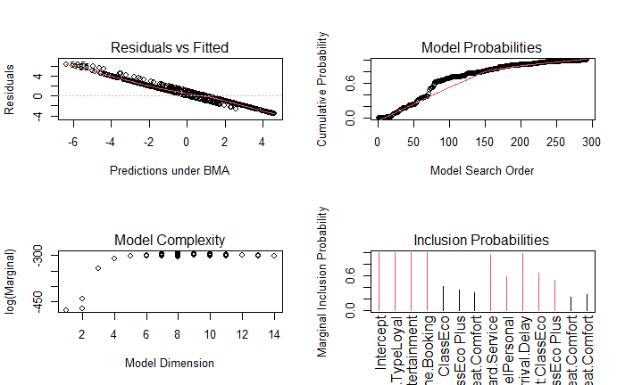

```r
par(mfrow = c(1, 1))
```

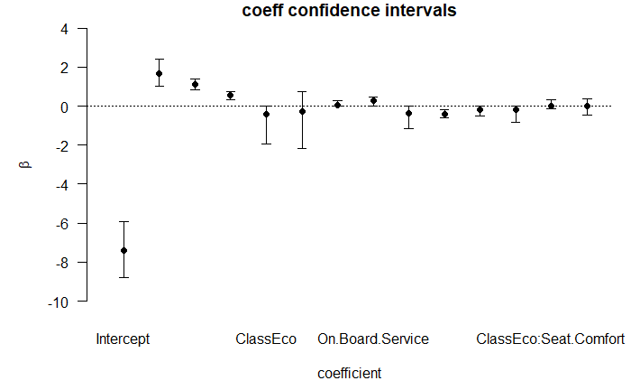

```r
plot(confint(coef(fit_int)), main="coeff confidence intervals")
```

```r
pip_int <- data.frame(
  variable = fit_int$namesx,
  PIP      = fit_int$probne0,
  coeff    = coef(fit_int)$postmean
)
pip_int <- pip_int[order(pip_int$PIP, decreasing = TRUE), ]
pip_int
```

|  | variable | PIP | coeff |
| --- | --- | --- | --- |
| 1 | Intercept | 1.0000000 | -7.3841739310 |
| 2 | Customer.TypeLoyal | 0.9998068 | 1.6876269379 |
| 3 | Inflight.Entertainment | 0.9988406 | 1.1075983087 |
| 4 | Ease.of.Online.Booking | 0.9987440 | 0.5577015146 |
| 10 | Arrival.Delay | 0.9929469 | -0.3917086294 |
| 8 | On.Board.Service | 0.9629952 | 0.3030165606 |
| 11 | Inflight.Entertainment:ClassEco | 0.6482126 | -0.1887073060 |
| 9 | Type.of.TravelPersonal | 0.5916908 | -0.3844368323 |
| 12 | Inflight.Entertainment:ClassEco Plus | 0.5235749 | -0.1901239552 |
| 5 | ClassEco | 0.4213527 | -0.4009533315 |

[output cut: 4 more lines]

**Conclusion on interactions**

The evidence for interactions is moderate rather than conclusive. The `Inflight.Entertainment × Class` terms are selected in the majority of visited models, providing suggestive evidence that entertainment quality matters more — or less — depending on travel class. However, given the limited improvement in R² and predictive performance relative to the full main-effects model, the interaction model is best interpreted as an exploratory finding rather than a definitive improvement. The full model without interactions remains the preferred specification for prediction.

# Predictive Exercise

In this section we evaluate the predictive performance of the Bayesian logistic regression model. We split the dataset into a **learning set** (used to fit the model) and a **test set** (held out for prediction).

First define some useful functions since we have to evaluate multiple models

```r
# compute metrics such as accuracy
# - pred: output of "predict(model, ...)"
# - threshold: predictions higher than "threshold" are considered "Satisfied"
evaluate_performance <- function(pred, threshold, dataset) {
  prob <- pred$fit

  pred <- ifelse(prob >= threshold, "Satisfied", "Dissatisfied")
  pred <- factor(pred, levels = levels(dataset$Satisfaction))

  acc <- mean(pred == dataset$Satisfaction)
  conf <- table(Predicted = pred, Actual = dataset$Satisfaction)

  sens <- conf["Satisfied",    "Satisfied"]    / sum(conf[, "Satisfied"])
  spec <- conf["Dissatisfied", "Dissatisfied"] / sum(conf[, "Dissatisfied"])

  list(
    accuracy = acc,
    sensitivity = sens,
    specificity = spec,
    conf_mat = conf
  )
}

# plot the predicted probabilities of two models
# - pred_1, pred_2: output of two "predict(model, ...)" (they have to use the same prediction dataset)
compare_predictions <- function(pred_1, pred_2, dataset, labelx = "Predictions 1", labely = "Predictions 2") {
  prob_1 <- as.numeric(pred_1$fit)
  prob_2 <- as.numeric(pred_2$fit)

  pred_df <- data.frame(
    data_1 = prob_1,
    data_2 = prob_2,
    Actual = dataset$Satisfaction
  )

  ggplot(pred_df, aes(x = data_1, y = data_2, color = Actual)) +
    geom_point(alpha = 0.5, size = 1.5) +
    geom_abline(slope = 1, intercept = 0, linetype = "dashed") +
    scale_color_manual(
      values = c("Dissatisfied" = "red", "Satisfied" = "forestgreen")
    ) +
    xlab(labelx) +
    ylab(labely) +
    ggtitle("Predictions Comparison") +
    theme_bw()
}

# plot the predicted probabilities of BMA and HPM estimators of the same model
compare_bma_hpc <- function(model, dataset) {
  pred_bma <- predict(model, newdata = dataset, estimator = "BMA")
  pred_hpm <- predict(model, newdata = dataset, estimator = "HPM")
  compare_predictions(pred_hpm, pred_bma, dataset, "HPM predicted", "BMA predicted")
}

# Prints the perfromance metrics
# - performance: the output of "evaluate_performance(...)"
print_performance <- function(performance) {
  cat("Accuracy:   ", round(performance$accuracy, 4), "\n")
  cat("Sensitivity:", round(performance$sensitivity, 4), "(Satisfied correctly identified)\n")
  cat("Specificity:", round(performance$specificity, 4), "(Dissatisfied correctly identified)\n")

  cat("\nConfusion matrix:\n")
  print(performance$conf_mat)
}

# Prints the performance metrics for two models
# - perf_1, perf_2: the output of "evaluate_performance(...)"
print_performances <- function(perf_1, perf_2, name_1 = "Model 1", name_2 = "Model 2") {
  cat(sprintf("             %-6s %-6s\n", name_1, name_2))
  cat("Accuracy:   ", round(perf_1$accuracy, 4), round(perf_2$accuracy, 4), "\n")
  cat("Sensitivity:", round(perf_1$sensitivity, 4), round(perf_2$sensitivity, 4), "(Satisfied correctly identified)\n")
  cat("Specificity:", round(perf_1$specificity, 4), round(perf_2$specificity, 4), "(Dissatisfied correctly identified)\n")

  cat("\nConfusion Matrix ", name_1, ":\n", sep = "")
  print(perf_1$conf_mat)
  cat("\nConfusion Matrix ", name_2, ":\n", sep = "")
  print(perf_2$conf_mat)
}

compute_roc <- function(dataset, probs) {
  roc(
    response  = as.numeric(dataset$Satisfaction) - 1,
    predictor = as.numeric(probs)
  )
}

# Plots ROC curves
# - rocs: a "list(...)" of the values returned by "compute_roc(...)"
# - palette: a "c(...)" of colors at least as long as "rocs" or NULL
# - legend: a "c(...)" of strings to display in the legend
plot_roc <- function(rocs, palette = NULL, title = NULL, legend) {
  if (is.null(title))
    title = "ROC curves"
  if (is.null(palette))
    palette = c("steelblue", "darkorange", "forestgreen", "purple", "red", "yellow", "cyan", "blue")

  plot(rocs[[1]], col = palette[1], lwd = 2, xlim = c(1, 0), main = title,
       print.auc = TRUE, print.auc.y = 0.5,
       print.thres = c(0.5), print.thres.adj = c(-0.05, 1.25), print.thres.pattern = "%.3f"
  )
  for (i in 2:length(rocs)) {
    plot(rocs[[i]], col = palette[i], lwd = 2, xlim = c(1, 0),
         print.auc = TRUE, print.auc.y = 0.5 - (i - 1) * 0.05,
         print.thres = c(0.5), print.thres.adj = c(-0.05, 1.25 + (i - 1) * 0.5), print.thres.pattern = "%.3f",
         add = TRUE
    )
  }
  legend("bottomright", legend = legend, col = palette, lwd = 2)
}

# Bar plot showing the selected metric for all trained models
# - metric: any scalar field in the return value of "evaluate_performance(...)"
plot_perf_comparison <- function(metric) {
  df <- data.frame(
    group = rep(c("Full", "Threshold", "Manual", "Initial"), each = 2),
    type  = rep(c("BMA", "HPM"), times = 4),
    value = c(test_full_bma_perf[[metric]], test_full_hpm_perf[[metric]],
              test_th_bma_perf[[metric]]  , test_th_hpm_perf[[metric]],
              test_man_bma_perf[[metric]] , test_man_hpm_perf[[metric]],
              test_init_bma_perf[[metric]], test_init_hpm_perf[[metric]])
  )

  ggplot(df, aes(x = group, y = value, fill = type)) +
    geom_col(position = "dodge") +
    coord_cartesian(ylim = c(0, 1)) +
    theme_minimal() +
    labs(x = "", y = "Value", fill = "Type")
}
```

## Full Model

### Predict Learning Set

We first obtain the fitted probabilities on the learning set (in-sample) and convert them to predicted classes using a 0.5 threshold, to get a baseline picture of how the model behaves on the data it was trained on.

```r
train_full_bma_pred <- predict(fit_full, estimator = "BMA")
train_full_hpm_pred <- predict(fit_full, estimator = "HPM")
train_full_bma_prob <- train_full_bma_pred$fit
```

```r
train_full_bma_perf <- evaluate_performance(train_full_bma_pred, 0.5, table_enc)
train_full_hpm_perf <- evaluate_performance(train_full_hpm_pred, 0.5, table_enc)

cat("Train set performance, BMA vs HPM:\n")
```

```
Train set performance, BMA vs HPM:
```

```r
print_performances(train_full_bma_perf, train_full_hpm_perf, "BMA", "HPM")
```

```
             BMA    HPM
Accuracy:    0.8451 0.8422
Sensitivity: 0.8672 0.8697 (Satisfied correctly identified)
Specificity: 0.8154 0.8054 (Dissatisfied correctly identified)

Confusion Matrix BMA:
              Actual
Predicted      Dissatisfied Satisfied
  Dissatisfied          243        53
  Satisfied              55       346

Confusion Matrix HPM:
              Actual
Predicted      Dissatisfied Satisfied
  Dissatisfied          240        52
  Satisfied              58       347
```

**BMA vs HPM**

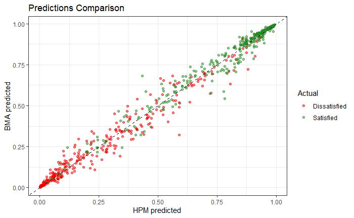

```r
compare_bma_hpc(fit_full, table_enc)
```

### Predict Test Set

We now predict on `test_enc`, i.e. the observations that were **not used to fit the model**. We obtain predictions under two estimators:

- **BMA** (Bayesian Model Averaging): averages predictions across all visited models, weighted by their posterior probability;
- **HPM** (Highest Posterior Model): uses only the single model with the largest posterior probability.

```r
test_full_bma_pred <- predict(fit_full, newdata = test_enc, estimator = "BMA")
test_full_hpm_pred <- predict(fit_full, newdata = test_enc, estimator = "HPM")

test_full_bma_prob <- test_full_bma_pred$fit
test_full_hpm_prob <- test_full_hpm_pred$fit
```

Below we plot the true response against the fitted and predicted probabilities. Black points are **in-sample** (learning set) and red points are **out-of-sample** (test set). A good model should show comparable spread between the two groups.

```r
# Combine in-sample and out-of-sample for a joint plot
plot(
  train_full_bma_prob,
  as.numeric(table_enc$Satisfaction) - 1.01,
  pch  = 16,
  xlab = expression(hat(p)),
  ylab = "Observed (0 = Dissatisfied, 1 = Satisfied)",
  main = "Fitted (black) vs predicted (red) probabilities"
)
points(
  test_full_bma_prob,
  as.numeric(test_enc$Satisfaction) - 0.99,
  pch = 16,
  col = "red"
)
```

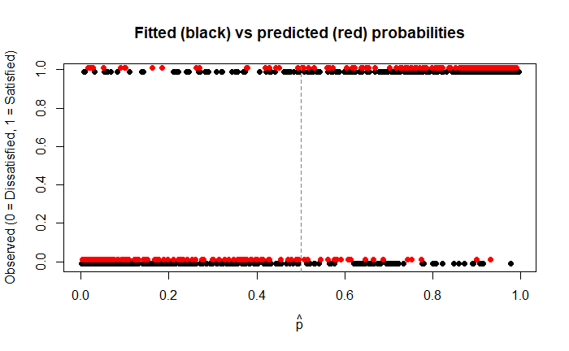

```r
abline(v = 0.5, lty = 2, col = "gray50")
```

- The model is well-separated: most predictions are concentrated near$\hat{p}$≈0 or $\hat{p}$≈1, meaning the model is generally confident in its classifications rather than uncertain around 0.5. This is a sign that the selected predictors carry strong discriminative information.
- The 0.5 threshold works well: points on y = 1 are predominantly on the right of the dashed line, and points on y = 0 are predominantly on the left, confirming that the 0.5 cutoff correctly separates the two classes in most cases.
- Misclassified observations are those where y = 1 but $\hat{p}$<0.5 (satisfied customers predicted as dissatisfied, visible on the left side of the y = 1 line) and vice versa. These are relatively few, consistent with the accuracy we computed.
- Red and black points overlap closely, indicating that the model generalises well from the learning set to the test set, with no obvious signs of overfitting.

**BMA vs HPM**

The scatter plot below compares the predicted probabilities under BMA and HPM on the test set. Points on the 45-degree dashed line indicate identical predictions; deviations show where the two estimators disagree. BMA predictions tend to be slightly more conservative (pulled toward 0.5) because they average over models rather than committing to a single one.

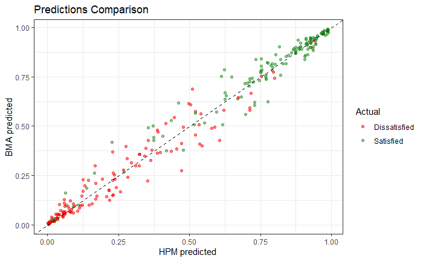

```r
compare_bma_hpc(fit_full, test_enc)
```

The plot compares the predicted probabilities of the two estimators on the test set, with points coloured by the true class.

- **BMA and HPM agree closely**: almost all points lie very near the 45-degree dashed line, meaning the two estimators produce nearly identical predictions in this dataset. This is a reassuring sign: the data are informative enough that the posterior is concentrated around a single dominant model, so averaging across models (BMA) or picking the best one (HPM) leads to the same conclusion.
- **BMA is slightly more conservative than HPM**: points tend to fall marginally *above* the diagonal for low predicted probabilities and *below* for high ones. In other words, BMA pulls predictions slightly toward 0.5 compared to HPM. This is the expected behaviour: BMA averages over models of varying complexity, and the simpler models included in the average shrink predictions toward the prior, while HPM commits fully to the single most probable model.
- **The two classes are well separated**: green points (Satisfied) cluster in the upper-right region ( $\hat{p}$ close to 1 for both estimators) and red points (Dissatisfied) cluster in the lower-left ( $\hat{p}$ close to 0). The overlap between the two colours is limited, confirming the good discriminative ability of the model already observed in the previous plot.
- **Most disagreement between BMA and HPM occurs in the intermediate range** ( $\hat{p}$≈0.25–0.60), which is exactly where model uncertainty matters most. Outside this range the predictions are nearly identical, because a predicted probability close to 0 or 1 is robust to which model is selected.

**Classification Performance**

We threshold the BMA and HPM probabilities at 0.5 and compare the resulting classifications with the true labels.

```r
test_full_bma_perf <- evaluate_performance(test_full_bma_pred, 0.5, test_enc)
test_full_hpm_perf <- evaluate_performance(test_full_hpm_pred, 0.5, test_enc)

cat("Test set performance, BMA vs HPM:\n")
```

```
Test set performance, BMA vs HPM:
```

```r
print_performances(test_full_bma_perf, test_full_hpm_perf, "BMA", "HPM")
```

```
             BMA    HPM
Accuracy:    0.8667 0.8467
Sensitivity: 0.8675 0.8494 (Satisfied correctly identified)
Specificity: 0.8657 0.8433 (Dissatisfied correctly identified)

Confusion Matrix BMA:
              Actual
Predicted      Dissatisfied Satisfied
  Dissatisfied          116        22
  Satisfied              18       144

Confusion Matrix HPM:
              Actual
Predicted      Dissatisfied Satisfied
  Dissatisfied          113        25
  Satisfied              21       141
```

The out-of-sample results confirm that both estimators generalise well to unseen data, with BMA outperforming HPM slightly.

Overall, an accuracy above 80% with balanced sensitivity and specificity on held-out data, using a model estimated purely on Bayesian principles with no manual tuning of the decision threshold, is a strong result and confirms that the selected predictors carry genuine and replicable signal about passenger satisfaction.

**AUC**

The **Area Under the ROC Curve (AUC)** evaluates the model’s discriminative ability across *all possible classification thresholds*, not just the 0.5 cutoff used for accuracy. The ROC curve plots sensitivity (true positive rate) against 1 − specificity (false positive rate) as the threshold varies from 0 to 1. An AUC of 0.5 corresponds to a random classifier, while an AUC of 1 indicates perfect separation between the two classes.

```r
# AUC — BMA
test_full_bma_roc <- compute_roc(test_enc, test_full_bma_prob)
test_full_bma_auc <- auc(test_full_bma_roc)

# AUC — HPM
test_full_hpm_roc <- compute_roc(test_enc, test_full_hpm_prob)
test_full_hpm_auc <- auc(test_full_hpm_roc)

cat("BMA - AUC:", round(test_full_bma_auc, 4), "\n")
```

```
BMA - AUC: 0.9136
```

```r
cat("HPM - AUC:", round(test_full_hpm_auc, 4), "\n")
```

```
HPM - AUC: 0.9039
```

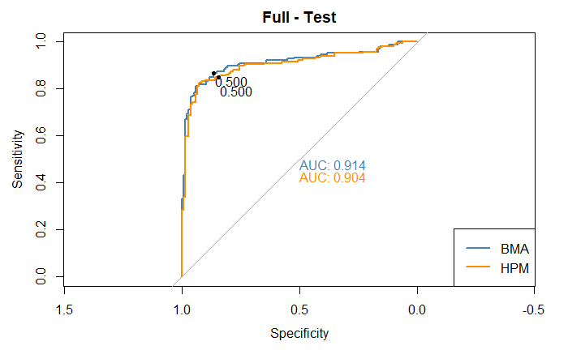

```r
plot_roc(rocs = list(test_full_bma_roc, test_full_hpm_roc), legend = c("BMA", "HPM"), title = "Full - Test")
```

The ROC curves confirm this: they rise steeply toward the upper-left corner of the plot, meaning the model achieves high sensitivity while keeping the false positive rate low, across virtually every threshold. This is consistent with the well-separated predicted probability distributions observed earlier.

## Initial Model

### Predict Learning Set

```r
train_init_bma_pred <- predict(fit, estimator = "BMA")
train_init_hpm_pred <- predict(fit, estimator = "HPM")
train_init_bma_prob <- train_full_bma_pred$fit
```

```r
train_init_bma_perf <- evaluate_performance(train_init_bma_pred, 0.5, table_enc)
train_init_hpm_perf <- evaluate_performance(train_init_hpm_pred, 0.5, table_enc)

cat("Train set performance, BMA vs HPM:\n")
```

```
Train set performance, BMA vs HPM:
```

```r
print_performances(train_init_bma_perf, train_init_hpm_perf, "BMA", "HPM")
```

```
             BMA    HPM
Accuracy:    0.7231 0.7202
Sensitivity: 0.792 0.792 (Satisfied correctly identified)
Specificity: 0.6309 0.6242 (Dissatisfied correctly identified)

Confusion Matrix BMA:
              Actual
Predicted      Dissatisfied Satisfied
  Dissatisfied          188        83
  Satisfied             110       316

Confusion Matrix HPM:
              Actual
Predicted      Dissatisfied Satisfied
  Dissatisfied          186        83
  Satisfied             112       316
```

**BMA vs HPM**

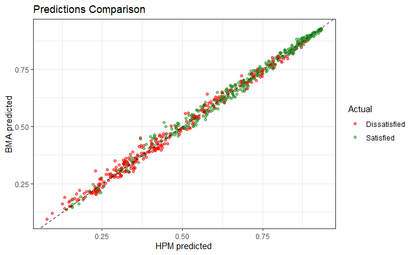

```r
compare_bma_hpc(fit, table_enc)
```

### Predict Test Set

```r
test_init_bma_pred <- predict(fit, newdata = test_enc, estimator = "BMA")
test_init_hpm_pred <- predict(fit, newdata = test_enc, estimator = "HPM")

test_init_bma_prob <- test_init_bma_pred$fit
test_init_hpm_prob <- test_init_hpm_pred$fit
```

```r
# Combine in-sample and out-of-sample for a joint plot
plot(
  train_init_bma_prob,
  as.numeric(table_enc$Satisfaction) - 1.01,
  pch  = 16,
  xlab = expression(hat(p)),
  ylab = "Observed (0 = Dissatisfied, 1 = Satisfied)",
  main = "Fitted (black) vs predicted (red) probabilities"
)
points(
  test_init_bma_prob,
  as.numeric(test_enc$Satisfaction) - 0.99,
  pch = 16,
  col = "red"
)
```

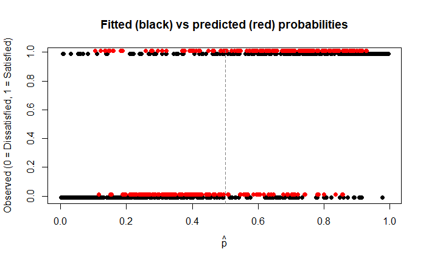

```r
abline(v = 0.5, lty = 2, col = "gray50")
```

**BMA vs HPM**

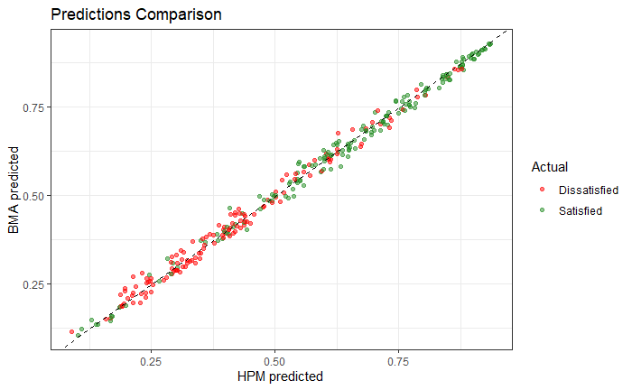

```r
compare_bma_hpc(fit, test_enc)
```

**Classification Performance**

```r
test_init_bma_perf <- evaluate_performance(test_init_bma_pred, 0.5, test_enc)
test_init_hpm_perf <- evaluate_performance(test_init_hpm_pred, 0.5, test_enc)

cat("Test set performance, BMA vs HPM:\n")
```

```
Test set performance, BMA vs HPM:
```

```r
print_performances(test_init_bma_perf, test_init_hpm_perf, "BMA", "HPM")
```

```
             BMA    HPM
Accuracy:    0.7433 0.7433
Sensitivity: 0.759 0.7711 (Satisfied correctly identified)
Specificity: 0.7239 0.709 (Dissatisfied correctly identified)

Confusion Matrix BMA:
              Actual
Predicted      Dissatisfied Satisfied
  Dissatisfied           97        40
  Satisfied              37       126

Confusion Matrix HPM:
              Actual
Predicted      Dissatisfied Satisfied
  Dissatisfied           95        38
  Satisfied              39       128
```

**AUC**

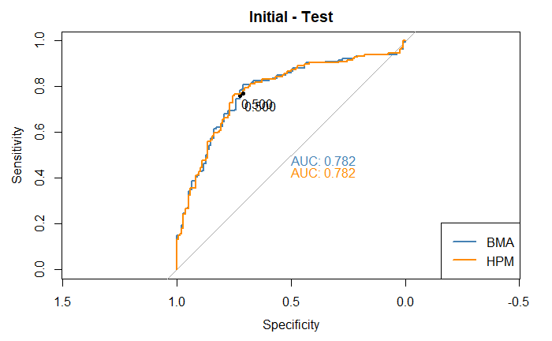

```r
test_init_bma_roc <- compute_roc(test_enc, test_init_bma_prob)
test_init_hpm_roc <- compute_roc(test_enc, test_init_hpm_prob)

plot_roc(rocs = list(test_init_bma_roc, test_init_hpm_roc), legend = c("BMA", "HPM"), title = "Initial - Test")
```

## Threshold Selection Model

### Predict Learning Set

```r
train_th_bma_pred <- predict(fit_th, estimator = "BMA")
train_th_hpm_pred <- predict(fit_th, estimator = "HPM")
train_th_bma_prob <- train_full_bma_pred$fit
```

```r
train_th_bma_perf <- evaluate_performance(train_th_bma_pred, 0.5, table_enc)
train_th_hpm_perf <- evaluate_performance(train_th_hpm_pred, 0.5, table_enc)

cat("Train set performance, BMA vs HPM:\n")
```

```
Train set performance, BMA vs HPM:
```

```r
print_performances(train_th_bma_perf, train_th_hpm_perf, "BMA", "HPM")
```

```
             BMA    HPM
Accuracy:    0.8436 0.8422
Sensitivity: 0.8747 0.8747 (Satisfied correctly identified)
Specificity: 0.802 0.7987 (Dissatisfied correctly identified)

Confusion Matrix BMA:
              Actual
Predicted      Dissatisfied Satisfied
  Dissatisfied          239        50
  Satisfied              59       349

Confusion Matrix HPM:
              Actual
Predicted      Dissatisfied Satisfied
  Dissatisfied          238        50
  Satisfied              60       349
```

**BMA vs HPM**

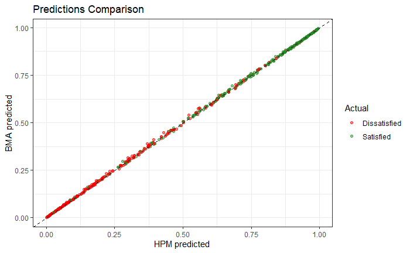

```r
compare_bma_hpc(fit_th, table_enc)
```

### Predict Test Set

```r
test_th_bma_pred <- predict(fit_th, newdata = test_enc, estimator = "BMA")
test_th_hpm_pred <- predict(fit_th, newdata = test_enc, estimator = "HPM")

test_th_bma_prob <- test_th_bma_pred$fit
test_th_hpm_prob <- test_th_hpm_pred$fit
```

```r
# Combine in-sample and out-of-sample for a joint plot
plot(
  train_th_bma_prob,
  as.numeric(table_enc$Satisfaction) - 1.01,
  pch  = 16,
  xlab = expression(hat(p)),
  ylab = "Observed (0 = Dissatisfied, 1 = Satisfied)",
  main = "Fitted (black) vs predicted (red) probabilities"
)
points(
  test_th_bma_prob,
  as.numeric(test_enc$Satisfaction) - 0.99,
  pch = 16,
  col = "red"
)
```

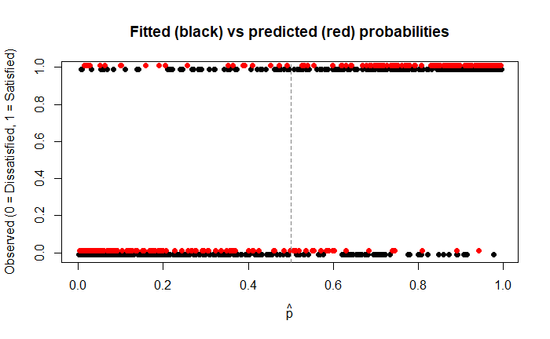

```r
abline(v = 0.5, lty = 2, col = "gray50")
```

**BMA vs HPM**

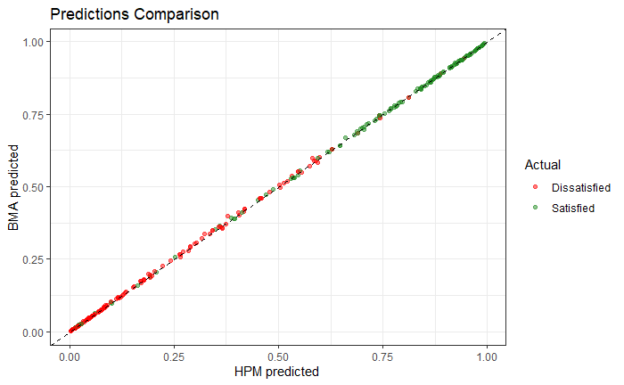

```r
compare_bma_hpc(fit_th, test_enc)
```

**Classification Performance**

```r
test_th_bma_perf <- evaluate_performance(test_th_bma_pred, 0.5, test_enc)
test_th_hpm_perf <- evaluate_performance(test_th_hpm_pred, 0.5, test_enc)

cat("Test set performance, BMA vs HPM:\n")
```

```
Test set performance, BMA vs HPM:
```

```r
print_performances(test_th_bma_perf, test_th_hpm_perf, "BMA", "HPM")
```

```
             BMA    HPM
Accuracy:    0.85 0.8467
Sensitivity: 0.8554 0.8554 (Satisfied correctly identified)
Specificity: 0.8433 0.8358 (Dissatisfied correctly identified)

Confusion Matrix BMA:
              Actual
Predicted      Dissatisfied Satisfied
  Dissatisfied          113        24
  Satisfied              21       142

Confusion Matrix HPM:
              Actual
Predicted      Dissatisfied Satisfied
  Dissatisfied          112        24
  Satisfied              22       142
```

**AUC**

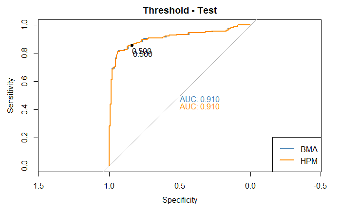

```r
test_th_bma_roc <- compute_roc(test_enc, test_th_bma_prob)
test_th_hpm_roc <- compute_roc(test_enc, test_th_hpm_prob)

plot_roc(rocs = list(test_th_bma_roc, test_th_hpm_roc), legend = c("BMA", "HPM"), title = "Threshold - Test")
```